# Module 169

#### Hemi-module gene counts:

345 probesets in hemi-module A.  
20 probesets in hemi-module B.  
Note: While the mapping of probesets to genes is usually one-to-one, some genes are targeted by multiple probesets, some probesets target multiple genes, and some probesets do not target any genes (i.e., the region of the genome they match is no longer considered genic).

#### Contrast SVE:

Signed variance explained (SVE) provides an indication of how similar a set of fold changes are to a gene module’s weight vector. An SVE value of 0.3, for example, indicates that 30% of the variance explained by the entire module set is accounted for by the module in question. Shown here are the SVE values for this module across a compendium of fold changes (contrasts). Extreme SVE values (e.g., > 0.05) indicate that those contrasts specifically induce (orange dots) or specifically repress (blue dots) this module. Examining the experimental conditions being compared in such contrasts (see tables below the figure) may provide insight into the gene module’s function.

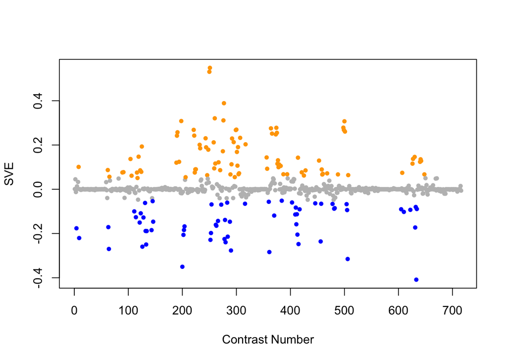

Positive SVE Contrasts:

|  | Contrast.Num | SVE | GEO.GSE | Cond.1 | Cond.2 | Mutation |
| --- | --- | --- | --- | --- | --- | --- |
| GSE42192.s2t1.vs.s0t1 | 251 | 0.55 | GSE42192 | C.elegans fed with CNCM I-4317 3 days rep1 | C.elegans fed with E.coli OP50 3 days rep1 |  |
| GSE42192.s1t1.vs.s0t1 | 250 | 0.53 | GSE42192 | C.elegans fed with CNCM I-3690 3 days rep1 | C.elegans fed with E.coli OP50 3 days rep1 |  |
| GSE41366B.s2t3.vs.s0t3 | 277 | 0.39 | GSE41366 | high_DDVP-8h_expose-26h_harvest-rep1 | control-8h_expose-26h_harvest-rep1 |  |
| GSE41366A.s2t4.vs.s0t4 | 260 | 0.32 | GSE41366 | high_DDVP-2h_expose-26h_harvest-rep1 | control-2h_expose-26h_harvest-rep1 |  |
| GSE41366B.s1t2.vs.s0t2 | 276 | 0.31 | GSE41366 | low_DDVP-8h_expose-20h_harvest-rep1 | control-8h_expose-20h_harvest-rep1 |  |
| GSE43959.s3t2.vs.s4t2 | 198 | 0.31 | GSE43959 | N2 gravid adult on Comamonas DA1877 rep 1 | N2 gravid adult on 1:1000 Comamonas DA1877 rep 1 |  |
| GSE23013.s2t1.vs.s0t1 | 500 | 0.31 | GSE23013 | young adult_24hr Formaldehyde exposure_rep1 | young adult_not exposed_rep1 |  |
| GSE23013.s4t1.vs.s0t1 | 498 | 0.28 | GSE23013 | young adult_24hr Benzene exposure_rep1 | young adult_not exposed_rep1 |  |
| GSE35354A.s1t4.vs.s1t1 | 374 | 0.28 | GSE35354 | Q200_rep1 | Q control_rep1 |  |
| GSE36358.s1t1.vs.s0t1 | 364 | 0.28 | GSE36358 | Ground Control (operation site) | Ground Control (Tsukuba space center) |  |
| GSE41366C.s2t3.vs.s2t1 | 300 | 0.27 | GSE41366 | high_DDVP-continuous_expose-14h_harvest-rep1 | high_DDVP-continuous_expose-2h_harvest-rep1 |  |
| GSE42592A.s0t2.vs.s0t1 | 221 | 0.27 | GSE42592 | acrylamide_control_expose-4h_rep1 | acrylamide_control_expose-0h_rep1 |  |
| GSE23013.s3t1.vs.s0t1 | 499 | 0.27 | GSE23013 | young adult_24hr BTF mix exposure_rep1 | young adult_not exposed_rep1 |  |
| GSE41366C.s0t3.vs.s0t1 | 299 | 0.27 | GSE41366 | control-continuous_expose-8h_harvest-rep1 | control-continuous_expose-0h_harvest-rep2 |  |
| GSE23013.s1t1.vs.s0t1 | 501 | 0.26 | GSE23013 | young adult_24hr Toluene exposure_rep1 | young adult_not exposed_rep1 |  |
| GSE46291.s2t2.vs.s2t1 | 191 | 0.26 | GSE46291 | L4-lethargus_rep1 | L3-lethargus_rep1 |  |
| GSE35354A.s1t2.vs.s1t1 | 375 | 0.26 | GSE35354 | Q50_rep1 | Q control_rep1 |  |
| GSE36358.s4t1.vs.s0t1 | 366 | 0.25 | GSE36358 | Space Flight | Ground Control (Tsukuba space center) |  |
| GSE35354A.s1t3.vs.s1t1 | 373 | 0.25 | GSE35354 | Q100_rep1 | Q control_rep1 |  |
| GSE42592A.s0t3.vs.s0t1 | 222 | 0.24 | GSE42592 | acrylamide_control_expose-8h_rep1 | acrylamide_control_expose-0h_rep1 |  |
| GSE46291.s1t2.vs.s1t1 | 190 | 0.24 | GSE46291 | L4_rep1 | L3_rep1 |  |
| GSE41366C.s1t2.vs.s1t1 | 307 | 0.23 | GSE41366 | low_DDVP-continuous_expose-8h_harvest-rep1 | low_DDVP-continuous_expose-2h_harvest-rep1 |  |
| GSE42592C.s0t2.vs.s0t1 | 243 | 0.23 | GSE42592 | mercury_control_expose-4h_rep1 | mercury_control_expose-0h_rep1 |  |
| GSE41366C.s1t2.vs.s0t2 | 292 | 0.23 | GSE41366 | low_DDVP-continuous_expose-8h_harvest-rep1 | control-continuous_expose-2h_harvest-rep1 |  |
| GSE41366C.s0t4.vs.s0t1 | 295 | 0.21 | GSE41366 | control-continuous_expose-14h_harvest-rep1 | control-continuous_expose-0h_harvest-rep2 |  |
| GSE41366A.s2t3.vs.s0t3 | 258 | 0.21 | GSE41366 | high_DDVP-2h_expose-20h_harvest-rep1 | control-2h_expose-20h_harvest-rep1 |  |
| GSE39145.s1t1.vs.s0t1 | 317 | 0.20 | GSE39145 | ercc-1_I | wild-type_N2_I | ercc-1 |
| GSE42592B.s0t2.vs.s0t1 | 232 | 0.20 | GSE42592 | cadmium_control_expose-4h_rep1 | cadmium_control_expose-0h_rep1 |  |
| GSE54024.s1t1.vs.s2t1 | 125 | 0.19 | GSE54024 | Wild type young adults, biological rep 1 | Wild type young adults treated with 0.1mM paraquat, biological rep 1 |  |
| GSE41366C.s2t2.vs.s2t1 | 303 | 0.19 | GSE41366 | high_DDVP-continuous_expose-8h_harvest-rep1 | high_DDVP-continuous_expose-2h_harvest-rep1 |  |

[output cut: 62 more lines]

Negative SVE Contrasts:

|  | Contrast.Num | SVE | GEO.GSE | Cond.1 | Cond.2 | Mutation |
| --- | --- | --- | --- | --- | --- | --- |
| GSE19310B.s1t3.vs.s1t1 | 633 | -0.41 | GSE19310 | N2 at 200 for 6 hours, rep1 | N2 at 200 for 15min, rep1 |  |
| GSE43959.s1t2.vs.s3t2 | 200 | -0.35 | GSE43959 | N2 gravid adult on E. coli OP50 rep 1 | N2 gravid adult on Comamonas DA1877 rep 1 |  |
| GSE2210.s1t1.vs.s0t1 | 506 | -0.32 | GSE2210 | tom-1(nu468) Sample 1 | Wild type Sample 1 | tom-1 |
| GSE37432.s2t1.vs.s0t1 | 361 | -0.28 | GSE37432 | piwi n4503 nDf57 rep1 | N2 rep1 | prg-1;prg-2 |
| GSE41366C.s1t5.vs.s0t5 | 290 | -0.28 | GSE41366 | low_DDVP-continuous_expose-26h_harvest-rep1 | control-continuous_expose-20h_harvest-rep1 |  |
| GSE8696.s3t1.vs.s1t1 | 64 | -0.27 | GSE8696 | 500 uM hemin (500A) | 4 uM hemin (4A) |  |
| GSE54011.s1t1.vs.s0t1 | 126 | -0.26 | GSE54011 | Ce 0.05 mM Se | Ce 0 mM Se |  |
| GSE52064.s2t1.vs.s4t1 | 133 | -0.25 | GSE52064 | mes-4_1 | lin-54;mes-4_1 | lin-54 |
| GSE29951.s1t2.vs.s1t1 | 415 | -0.25 | GSE29951 | C.elegans MT KO mtl-1,mtl-2(zs1) raised in the presence of Cd, rep1 | C.elegans MT KO mtl-1,mtl-2(zs1), raised in the absence of Cd, rep1 | mtl-1;mtl-2 |
| GSE41366B.s0t3.vs.s0t1 | 280 | -0.24 | GSE41366 | control-8h_expose-26h_harvest-rep1 | control-8h_expose-14h_harvest-rep1 |  |
| GSE24847.s1t2.vs.s1t1 | 456 | -0.24 | GSE24847 | young adult_24hr MWCNT exposure_rep1 | young adult_0h MWCNT exposure_rep1 |  |
| GSE42192.s1t2.vs.s1t1 | 252 | -0.23 | GSE42192 | C.elegans fed with CNCM I-3690 10 days rep1 | C.elegans fed with CNCM I-3690 3 days rep1 |  |
| GSE41366B.s1t3.vs.s0t3 | 278 | -0.23 | GSE41366 | low_DDVP-8h_expose-26h_harvest-rep1 | control-8h_expose-26h_harvest-rep1 |  |
| GSE9897C.s1t1.vs.s0t1 | 9 | -0.22 | GSE9897 | Mutant, biological rep1 | Wildtype, biological rep1 |  |
| GSE41366B.s1t3.vs.s1t1 | 284 | -0.21 | GSE41366 | low_DDVP-8h_expose-26h_harvest-rep1 | low_DDVP-8h_expose-14h_harvest-rep1 |  |
| GSE43959.s1t2.vs.s1t1 | 202 | -0.21 | GSE43959 | N2 gravid adult on E. coli OP50 rep 1 | N2 young adult on E. coli OP50 rep 1 |  |
| GSE29951.s1t2.vs.s0t2 | 413 | -0.20 | GSE29951 | C.elegans MT KO mtl-1,mtl-2(zs1) raised in the presence of Cd, rep1 | C.elegans wild type raised in the presence of Cd, rep1 | mtl-1;mtl-2 |
| GSE42192.s2t2.vs.s2t1 | 253 | -0.20 | GSE42192 | C.elegans fed with CNCM I-4317 10 days rep1 | C.elegans fed with CNCM I-4317 3 days rep1 |  |
| GSE52064.s1t1.vs.s4t1 | 134 | -0.19 | GSE52064 | wildtype_1 | lin-54;mes-4_1 | lin-54;mes-4 |
| GSE52064.s1t1.vs.s3t1 | 132 | -0.19 | GSE52064 | wildtype_1 | lin-54_1 | lin-54 |
| GSE50513.s3t1.vs.s1t1 | 143 | -0.18 | GSE50513 | zip-2 OP50 - rep 1 | L4440 OP50 - rep 1 | zip-2 |
| GSE43952.s1t1.vs.s0t1 | 203 | -0.18 | GSE43952 | metr-1(ok521) fed Comamonas DA1877 rep 1 | N2 gravid adult fed Comamonas DA1877 rep 1 | metr-1 |
| GSE9897B.s1t1.vs.s0t1 | 4 | -0.18 | GSE9897 | Complex I RNAi Mutant 1 | Wildtype (control for RNAi) | F22D6.4 |
| GSE19310B.s1t4.vs.s1t1 | 631 | -0.17 | GSE19310 | N2 at 200 for 1 generation, rep1 | N2 at 200 for 15min, rep1 |  |
| GSE8696.s3t1.vs.s2t1 | 63 | -0.17 | GSE8696 | 500 uM hemin (500A) | 20 uM hemin (20A) |  |
| GSE43952.s2t1.vs.s0t1 | 204 | -0.17 | GSE43952 | pcca-1(ok2282) fed Comamonas DA1877 rep1 | N2 gravid adult fed Comamonas DA1877 rep 1 | pcca-1 |
| GSE41366A.s1t1.vs.s0t1 | 263 | -0.16 | GSE41366 | low_DDVP-2h_expose-8h_harvest-rep1 | control-2h_expose-8h_harvest-rep1 |  |
| GSE41366A.s2t1.vs.s0t1 | 262 | -0.16 | GSE41366 | high_DDVP-2h_expose-8h_harvest-rep1 | control-2h_expose-8h_harvest-rep1 |  |
| GSE30505.s2t2.vs.s2t1 | 411 | -0.16 | GSE30505 | Day 8 N2 (WT) ash-2 #1 | L3 N2 (WT) ash-2 #1 |  |
| GSE54024.s2t1.vs.s4t1 | 121 | -0.15 | GSE54024 | Wild type young adults treated with 0.1mM paraquat, biological rep 1 | isp-1(qm150) young adults, biological rep 1 |  |
| GSE41366C.s1t4.vs.s0t4 | 288 | -0.15 | GSE41366 | low_DDVP-continuous_expose-20h_harvest-rep1 | control-continuous_expose-14h_harvest-rep1 |  |
| GSE50513.s4t1.vs.s2t1 | 146 | -0.15 | GSE50513 | zip-2 PA14 - rep 1 | L4440 PA14 - rep 1 | zip-2 |
| GSE41366A.s0t4.vs.s0t1 | 266 | -0.14 | GSE41366 | control-2h_expose-26h_harvest-rep1 | control-2h_expose-8h_harvest-rep1 |  |
| GSE41366B.s0t2.vs.s0t1 | 279 | -0.14 | GSE41366 | control-8h_expose-20h_harvest-rep1 | control-8h_expose-14h_harvest-rep1 |  |
| GSE54011.s3t1.vs.s0t1 | 128 | -0.13 | GSE54011 | Ce 0.2 mM Se | Ce 0 mM Se |  |
| GSE54024.s2t1.vs.s5t1 | 114 | -0.13 | GSE54024 | Wild type young adults treated with 0.1mM paraquat, biological rep 1 | ced-4(n1162) young adults, biological rep 1 |  |
| GSE35360B.s2t1.vs.s0t1 | 370 | -0.12 | GSE35360 | HF 3d_2.0_rep1 | HF 3d control_rep1 |  |
| GSE30505.s4t2.vs.s4t1 | 409 | -0.11 | GSE30505 | Day 8 glp-1 ash-2 #1 | L3 glp-1 ash-2 #1 |  |
| GSE30505.s1t2.vs.s1t1 | 412 | -0.11 | GSE30505 | Day 8 N2 (WT) E.V. #1 | L3 N2 (WT) E.V. #1 |  |
| GSE54024.s2t1.vs.s3t1 | 123 | -0.11 | GSE54024 | Wild type young adults treated with 0.1mM paraquat, biological rep 1 | nuo-6(qm200) young adults, biological rep 1 |  |
| GSE21591.s3t1.vs.s5t1 | 610 | -0.10 | GSE21591 | GGF_aFLAG_1 | aFLAG_1 |  |
| GSE54024.s6t1.vs.s5t1 | 111 | -0.10 | GSE54024 | isp-1(qm150) ced-4(n1162) double mutant young adults, biological rep 1 | ced-4(n1162) young adults, biological rep 1 | isp-1 |
| GSE22660.s1t2.vs.s1t1 | 505 | -0.09 | GSE22660 | 1ug/ml ivermectin exposure, biological rep 1 | 100ng/ml ivermectin exposure, biological rep 1 |  |
| GSE21162.s1t1.vs.s0t1 | 622 | -0.09 | GSE21162 | PVD and OLL neurons, biological rep1 | L3/L4 stage whole animal reference, rep1 |  |
| GSE28856.s0t2.vs.s0t1 | 417 | -0.09 | GSE28856 | Wild-type 1 h after shifting temperature rep1 | Wild-type 0 h after shifting temperature rep1 |  |
| GSE21784.s2t1.vs.s3t1 | 605 | -0.09 | GSE21784 | day 6 adults, biological rep 1 | day 15 adults, biological rep 1 |  |
| GSE19138.s1t1.vs.s0t1 | 634 | -0.09 | GSE19138 | ALG-1(-) 1 | WT1 | alg-1 |
| GSE23528A.s2t6.vs.s2t1 | 481 | -0.09 | GSE23528 | Adult at T22 in WC, time-series experiment 1 | Adult at T2 in WC, time-series experiment 1 |  |
| GSE23528A.s2t2.vs.s2t1 | 482 | -0.09 | GSE23528 | Adult at T6 in WC, time-series experiment 1 | Adult at T2 in WC, time-series experiment 1 |  |
| GSE30505.s3t2.vs.s3t1 | 410 | -0.08 | GSE30505 | Day 8 glp-1 E.V. #1 | L3 glp-1 E.V. #1 |  |
| GSE19310B.s1t2.vs.s1t1 | 632 | -0.08 | GSE19310 | N2 at 200 for 1 hour, rep1 | N2 at 200 for 15min, rep1 |  |
| GSE41366A.s1t4.vs.s1t1 | 272 | -0.07 | GSE41366 | low_DDVP-2h_expose-26h_harvest-rep1 | low_DDVP-2h_expose-8h_harvest-rep1 |  |
| GSE42192.s0t2.vs.s0t1 | 254 | -0.07 | GSE42192 | C.elegans fed with E.coli OP50 10 days rep1 | C.elegans fed with E.coli OP50 3 days rep1 |  |
| GSE22660.s0t2.vs.s0t1 | 504 | -0.07 | GSE22660 | 1ug/ml DMSO control, biological rep 1 | 100ng/ml DMSO control, biological rep 1 |  |
| GSE23528A.s2t3.vs.s2t1 | 478 | -0.07 | GSE23528 | Adult at T10 in WC, time-series experiment 1 | Adult at T2 in WC, time-series experiment 1 |  |
| GSE24847.s1t3.vs.s1t1 | 457 | -0.07 | GSE24847 | young adult_4hr MWCNT exposure_rep1 | young adult_0h MWCNT exposure_rep1 |  |
| GSE39252.s1t1.vs.s0t1 | 316 | -0.07 | GSE39252 | xpa-1_rep1 | N2_rep1 | xpa-1 |
| GSE27401.s2t1.vs.s3t1 | 446 | -0.06 | GSE27401 | Heat Killed C. albicans #1 | C. albicans alive #1 |  |
| GSE52064.s2t1.vs.s3t1 | 131 | -0.06 | GSE52064 | mes-4_1 | lin-54_1 | mes-4 vs. lin-54 |
| GSE41366B.s1t2.vs.s1t1 | 283 | -0.06 | GSE41366 | low_DDVP-8h_expose-20h_harvest-rep1 | low_DDVP-8h_expose-14h_harvest-rep1 |  |
| GSE30505.s3t1.vs.s4t1 | 403 | -0.06 | GSE30505 | L3 glp-1 E.V. #1 | L3 glp-1 ash-2 #1 | ash-2 |
| GSE37432.s1t1.vs.s0t1 | 360 | -0.06 | GSE37432 | piwi n4357 n4358 rep1 | N2 rep1 | prg-1;prg-2 |
| GSE50513.s3t1.vs.s2t1 | 145 | -0.05 | GSE50513 | zip-2 OP50 - rep 1 | L4440 PA14 - rep 1 |  |
| GSE34026.s4t1.vs.s0t1 | 384 | -0.05 | GSE34026 | N2 exposed to CVD109, biological rep1 | N2 exposed to OP50(E.coli), biological rep1 |  |

$~$

#### Contrast SVE, Up-Regulated Genes Only:

Calculating SVE for up-regulated and down-regulated genes separately may be more informative in many cases than projecting the up- and down- gene sets together. This is due to the fact that the weight distribution of many modules is highly skewed, indicating that only one of the hemi-modules may be biologically meaningful (i.e., a set of genes are strongly correlated by only a few genes (or none) are strongly anti-correlated to that set.)

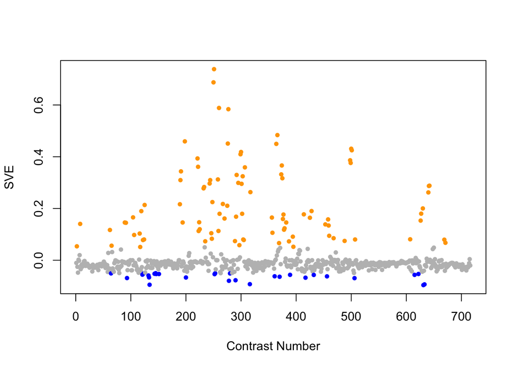

Positive SVE Contrasts:

|  | Contrast.Num | SVE | GEO.GSE | Cond.1 | Cond.2 | Mutation |
| --- | --- | --- | --- | --- | --- | --- |
| GSE42192.s2t1.vs.s0t1 | 251 | 0.74 | GSE42192 | C.elegans fed with CNCM I-4317 3 days rep1 | C.elegans fed with E.coli OP50 3 days rep1 |  |
| GSE42192.s1t1.vs.s0t1 | 250 | 0.69 | GSE42192 | C.elegans fed with CNCM I-3690 3 days rep1 | C.elegans fed with E.coli OP50 3 days rep1 |  |
| GSE41366A.s2t4.vs.s0t4 | 260 | 0.59 | GSE41366 | high_DDVP-2h_expose-26h_harvest-rep1 | control-2h_expose-26h_harvest-rep1 |  |
| GSE41366B.s2t3.vs.s0t3 | 277 | 0.58 | GSE41366 | high_DDVP-8h_expose-26h_harvest-rep1 | control-8h_expose-26h_harvest-rep1 |  |
| GSE36358.s4t1.vs.s0t1 | 366 | 0.48 | GSE36358 | Space Flight | Ground Control (Tsukuba space center) |  |
| GSE43959.s3t2.vs.s4t2 | 198 | 0.46 | GSE43959 | N2 gravid adult on Comamonas DA1877 rep 1 | N2 gravid adult on 1:1000 Comamonas DA1877 rep 1 |  |
| GSE41366B.s1t2.vs.s0t2 | 276 | 0.45 | GSE41366 | low_DDVP-8h_expose-20h_harvest-rep1 | control-8h_expose-20h_harvest-rep1 |  |
| GSE36358.s1t1.vs.s0t1 | 364 | 0.45 | GSE36358 | Ground Control (operation site) | Ground Control (Tsukuba space center) |  |
| GSE23013.s2t1.vs.s0t1 | 500 | 0.43 | GSE23013 | young adult_24hr Formaldehyde exposure_rep1 | young adult_not exposed_rep1 |  |
| GSE23013.s1t1.vs.s0t1 | 501 | 0.42 | GSE23013 | young adult_24hr Toluene exposure_rep1 | young adult_not exposed_rep1 |  |
| GSE41366C.s2t3.vs.s2t1 | 300 | 0.42 | GSE41366 | high_DDVP-continuous_expose-14h_harvest-rep1 | high_DDVP-continuous_expose-2h_harvest-rep1 |  |
| GSE41366C.s0t3.vs.s0t1 | 299 | 0.41 | GSE41366 | control-continuous_expose-8h_harvest-rep1 | control-continuous_expose-0h_harvest-rep2 |  |
| GSE42592A.s0t2.vs.s0t1 | 221 | 0.39 | GSE42592 | acrylamide_control_expose-4h_rep1 | acrylamide_control_expose-0h_rep1 |  |
| GSE23013.s4t1.vs.s0t1 | 498 | 0.39 | GSE23013 | young adult_24hr Benzene exposure_rep1 | young adult_not exposed_rep1 |  |
| GSE23013.s3t1.vs.s0t1 | 499 | 0.38 | GSE23013 | young adult_24hr BTF mix exposure_rep1 | young adult_not exposed_rep1 |  |
| GSE35354A.s1t4.vs.s1t1 | 374 | 0.37 | GSE35354 | Q200_rep1 | Q control_rep1 |  |
| GSE42592A.s0t3.vs.s0t1 | 222 | 0.36 | GSE42592 | acrylamide_control_expose-8h_rep1 | acrylamide_control_expose-0h_rep1 |  |
| GSE41366C.s1t2.vs.s1t1 | 307 | 0.36 | GSE41366 | low_DDVP-continuous_expose-8h_harvest-rep1 | low_DDVP-continuous_expose-2h_harvest-rep1 |  |
| GSE46291.s2t2.vs.s2t1 | 191 | 0.34 | GSE46291 | L4-lethargus_rep1 | L3-lethargus_rep1 |  |
| GSE35354A.s1t3.vs.s1t1 | 373 | 0.33 | GSE35354 | Q100_rep1 | Q control_rep1 |  |
| GSE41366C.s1t2.vs.s0t2 | 292 | 0.33 | GSE41366 | low_DDVP-continuous_expose-8h_harvest-rep1 | control-continuous_expose-2h_harvest-rep1 |  |
| GSE41366C.s2t2.vs.s2t1 | 303 | 0.32 | GSE41366 | high_DDVP-continuous_expose-8h_harvest-rep1 | high_DDVP-continuous_expose-2h_harvest-rep1 |  |
| GSE35354A.s1t2.vs.s1t1 | 375 | 0.32 | GSE35354 | Q50_rep1 | Q control_rep1 |  |
| GSE41366A.s2t3.vs.s0t3 | 258 | 0.31 | GSE41366 | high_DDVP-2h_expose-20h_harvest-rep1 | control-2h_expose-20h_harvest-rep1 |  |
| GSE46291.s1t2.vs.s1t1 | 190 | 0.31 | GSE46291 | L4_rep1 | L3_rep1 |  |
| GSE42592C.s0t3.vs.s0t1 | 244 | 0.31 | GSE42592 | mercury_control_expose-8h_rep1 | mercury_control_expose-0h_rep1 |  |
| GSE41366C.s0t4.vs.s0t1 | 295 | 0.30 | GSE41366 | control-continuous_expose-14h_harvest-rep1 | control-continuous_expose-0h_harvest-rep2 |  |
| GSE42592C.s0t2.vs.s0t1 | 243 | 0.30 | GSE42592 | mercury_control_expose-4h_rep1 | mercury_control_expose-0h_rep1 |  |
| GSE41366C.s2t4.vs.s2t1 | 301 | 0.30 | GSE41366 | high_DDVP-continuous_expose-20h_harvest-rep1 | high_DDVP-continuous_expose-2h_harvest-rep1 |  |
| GSE18132.s0t2.vs.s0t1 | 642 | 0.29 | GSE18132 | WT Fed L4, biological rep1 | WT Starved L1, biological rep1 |  |

[output cut: 66 more lines]

Negative SVE Contrasts:

|  | Contrast.Num | SVE | GEO.GSE | Cond.1 | Cond.2 | Mutation |
| --- | --- | --- | --- | --- | --- | --- |
| GSE19310B.s1t4.vs.s1t1 | 631 | -0.10 | GSE19310 | N2 at 200 for 1 generation, rep1 | N2 at 200 for 15min, rep1 |  |
| GSE52064.s1t1.vs.s4t1 | 134 | -0.09 | GSE52064 | wildtype_1 | lin-54;mes-4_1 | lin-54;mes-4 |
| GSE19310B.s1t3.vs.s1t1 | 633 | -0.09 | GSE19310 | N2 at 200 for 6 hours, rep1 | N2 at 200 for 15min, rep1 |  |
| GSE39252.s1t1.vs.s0t1 | 316 | -0.09 | GSE39252 | xpa-1_rep1 | N2_rep1 | xpa-1 |
| GSE41366B.s1t3.vs.s0t3 | 278 | -0.08 | GSE41366 | low_DDVP-8h_expose-26h_harvest-rep1 | control-8h_expose-26h_harvest-rep1 |  |
| GSE41366C.s1t5.vs.s0t5 | 290 | -0.08 | GSE41366 | low_DDVP-continuous_expose-26h_harvest-rep1 | control-continuous_expose-20h_harvest-rep1 |  |
| GSE2210.s1t1.vs.s0t1 | 506 | -0.07 | GSE2210 | tom-1(nu468) Sample 1 | Wild type Sample 1 | tom-1 |
| GSE5801.s3t1.vs.s1t1 | 93 | -0.07 | GSE5801 | daf2pmk1_RepA | daf2_RepA | pmk-1 |
| GSE28856.s0t2.vs.s0t1 | 417 | -0.07 | GSE28856 | Wild-type 1 h after shifting temperature rep1 | Wild-type 0 h after shifting temperature rep1 |  |
| GSE43959.s1t2.vs.s3t2 | 200 | -0.07 | GSE43959 | N2 gravid adult on E. coli OP50 rep 1 | N2 gravid adult on Comamonas DA1877 rep 1 |  |
| GSE52064.s2t1.vs.s4t1 | 133 | -0.07 | GSE52064 | mes-4_1 | lin-54;mes-4_1 | lin-54 |
| GSE35360B.s2t1.vs.s0t1 | 370 | -0.06 | GSE35360 | HF 3d_2.0_rep1 | HF 3d control_rep1 |  |
| GSE24847.s1t2.vs.s1t1 | 456 | -0.06 | GSE24847 | young adult_24hr MWCNT exposure_rep1 | young adult_0h MWCNT exposure_rep1 |  |
| GSE37432.s2t1.vs.s0t1 | 361 | -0.06 | GSE37432 | piwi n4503 nDf57 rep1 | N2 rep1 | prg-1;prg-2 |
| GSE52064.s1t1.vs.s3t1 | 132 | -0.06 | GSE52064 | wildtype_1 | lin-54_1 | lin-54 |
| GSE27677A.s2t2.vs.s2t1 | 432 | -0.06 | GSE27677 | jun-1, Fast , rep 1 | jun-1, Fed , rep 1 |  |
| GSE21591.s1t1.vs.s4t1 | 615 | -0.06 | GSE21591 | N2_aFLAG_1 | aMYC_1 |  |
| GSE32942.s2t1.vs.s1t1 | 389 | -0.06 | GSE32942 | WS5041 (mir 58(n4640); alg 1(tm492); opIs205). Replicate 1 | WS4303 (alg 1(tm492); opIs205). Replicate 1 | mir-58 |
| GSE54024.s2t1.vs.s4t1 | 121 | -0.06 | GSE54024 | Wild type young adults treated with 0.1mM paraquat, biological rep 1 | isp-1(qm150) young adults, biological rep 1 |  |
| GSE42192.s1t2.vs.s1t1 | 252 | -0.05 | GSE42192 | C.elegans fed with CNCM I-3690 10 days rep1 | C.elegans fed with CNCM I-3690 3 days rep1 |  |
| GSE50513.s4t1.vs.s2t1 | 146 | -0.05 | GSE50513 | zip-2 PA14 - rep 1 | L4440 PA14 - rep 1 | zip-2 |
| GSE21162.s1t1.vs.s0t1 | 622 | -0.05 | GSE21162 | PVD and OLL neurons, biological rep1 | L3/L4 stage whole animal reference, rep1 |  |
| GSE47778.s4t1.vs.s3t1 | 151 | -0.05 | GSE47778 | daf-2;daf-16; replicate 1 | daf-16; replicate 1 | daf-2;daf-16 vs. daf-16 |
| GSE50513.s3t1.vs.s1t1 | 143 | -0.05 | GSE50513 | zip-2 OP50 - rep 1 | L4440 OP50 - rep 1 | zip-2 |
| GSE54024.s2t1.vs.s3t1 | 123 | -0.05 | GSE54024 | Wild type young adults treated with 0.1mM paraquat, biological rep 1 | nuo-6(qm200) young adults, biological rep 1 |  |
| GSE41366B.s0t3.vs.s0t1 | 280 | -0.05 | GSE41366 | control-8h_expose-26h_harvest-rep1 | control-8h_expose-14h_harvest-rep1 |  |
| GSE8696.s3t1.vs.s1t1 | 64 | -0.05 | GSE8696 | 500 uM hemin (500A) | 4 uM hemin (4A) |  |
| GSE42192.s2t2.vs.s2t1 | 253 | -0.05 | GSE42192 | C.elegans fed with CNCM I-4317 10 days rep1 | C.elegans fed with CNCM I-4317 3 days rep1 |  |
| GSE50513.s3t1.vs.s2t1 | 145 | -0.05 | GSE50513 | zip-2 OP50 - rep 1 | L4440 PA14 - rep 1 |  |

$~$

#### Contrast SVE, Down-Regulated Genes Only:

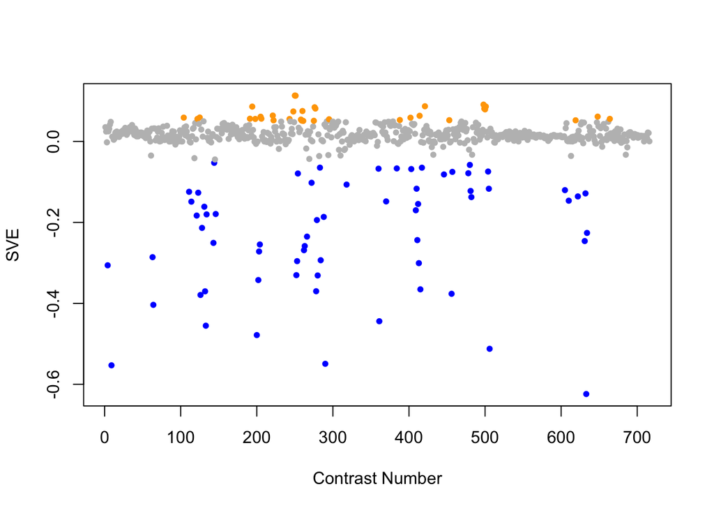

Positive SVE Contrasts:

|  | Contrast.Num | SVE | GEO.GSE | Cond.1 | Cond.2 | Mutation |
| --- | --- | --- | --- | --- | --- | --- |
| GSE42192.s1t1.vs.s0t1 | 250 | 0.11 | GSE42192 | C.elegans fed with CNCM I-3690 3 days rep1 | C.elegans fed with E.coli OP50 3 days rep1 |  |
| GSE42192.s2t1.vs.s0t1 | 251 | 0.11 | GSE42192 | C.elegans fed with CNCM I-4317 3 days rep1 | C.elegans fed with E.coli OP50 3 days rep1 |  |
| GSE23013.s4t1.vs.s0t1 | 498 | 0.09 | GSE23013 | young adult_24hr Benzene exposure_rep1 | young adult_not exposed_rep1 |  |
| GSE28494.s1t2.vs.s0t2 | 421 | 0.09 | GSE28494 | lin-54(n3423) dissected germline 1 | wild-type N2 dissected germline 1 | lin-54 |
| GSE23013.s1t1.vs.s0t1 | 501 | 0.09 | GSE23013 | young adult_24hr Toluene exposure_rep1 | young adult_not exposed_rep1 |  |
| GSE44318.s1t1.vs.s0t1 | 194 | 0.09 | GSE44318 | 13L peptide [SL12] | NGM [SL1] |  |
| GSE41366B.s1t2.vs.s0t2 | 276 | 0.08 | GSE41366 | low_DDVP-8h_expose-20h_harvest-rep1 | control-8h_expose-20h_harvest-rep1 |  |
| GSE41366B.s2t3.vs.s0t3 | 277 | 0.08 | GSE41366 | high_DDVP-8h_expose-26h_harvest-rep1 | control-8h_expose-26h_harvest-rep1 |  |
| GSE23013.s3t1.vs.s0t1 | 499 | 0.08 | GSE23013 | young adult_24hr BTF mix exposure_rep1 | young adult_not exposed_rep1 |  |
| GSE23013.s2t1.vs.s0t1 | 500 | 0.08 | GSE23013 | young adult_24hr Formaldehyde exposure_rep1 | young adult_not exposed_rep1 |  |
| GSE41366A.s2t4.vs.s0t4 | 260 | 0.08 | GSE41366 | high_DDVP-2h_expose-26h_harvest-rep1 | control-2h_expose-26h_harvest-rep1 |  |
| GSE42192.s1t2.vs.s0t2 | 248 | 0.07 | GSE42192 | C.elegans fed with CNCM I-3690 10 days rep1 | C.elegans fed with E.coli OP50 10 days rep1 |  |
| GSE42592A.s0t2.vs.s0t1 | 221 | 0.06 | GSE42592 | acrylamide_control_expose-4h_rep1 | acrylamide_control_expose-0h_rep1 |  |
| GSE29951.s1t1.vs.s0t1 | 414 | 0.06 | GSE29951 | C.elegans MT KO mtl-1,mtl-2(zs1), raised in the absence of Cd, rep1 | C.elegans wild type raised in the absence of Cd, rep1 | mtl-1;mtl-2 |
| GSE16753.s1t1.vs.s0t1 | 648 | 0.06 | GSE16753 | fer-1 (hc24ts) mutant young adult biological rep 1 | Wild-type young adult biological rep 3 | fer-1 |
| GSE42703.s2t1.vs.s1t1 | 205 | 0.06 | GSE42703 | WT incubated with 1mM copper sulfate, biological rep1 | kgb-1 incubated with 1mM copper sulfate, biological rep1 | kgb-1 |
| GSE54024.s1t1.vs.s2t1 | 125 | 0.06 | GSE54024 | Wild type young adults, biological rep 1 | Wild type young adults treated with 0.1mM paraquat, biological rep 1 |  |
| GSE57664.s1t1.vs.s0t1 | 104 | 0.06 | GSE57664 | TYR treated rep1 | control rep1 |  |
| GSE30505.s1t2.vs.s2t2 | 402 | 0.06 | GSE30505 | Day 8 N2 (WT) E.V. #1 | Day 8 N2 (WT) ash-2 #1 | ash-2 |
| GSE42703.s2t2.vs.s1t2 | 206 | 0.06 | GSE42703 | WT incubated with H2O, biological rep1 | kgb-1 incubated with H2O, biological rep1 | kgb-1 |
| GSE46291.s2t2.vs.s2t1 | 191 | 0.06 | GSE46291 | L4-lethargus_rep1 | L3-lethargus_rep1 |  |
| GSE15159.s2t2.vs.s0t2 | 664 | 0.06 | GSE15159 | xpa-1_UV_2007_rep1 | N2_UV_2007_rep1 | xpa-1 |
| GSE54024.s1t1.vs.s4t1 | 122 | 0.06 | GSE54024 | Wild type young adults, biological rep 1 | isp-1(qm150) young adults, biological rep 1 | isp-1 |
| GSE43959.s3t2.vs.s4t2 | 198 | 0.06 | GSE43959 | N2 gravid adult on Comamonas DA1877 rep 1 | N2 gravid adult on 1:1000 Comamonas DA1877 rep 1 |  |
| GSE42592C.s0t2.vs.s0t1 | 243 | 0.06 | GSE42592 | mercury_control_expose-4h_rep1 | mercury_control_expose-0h_rep1 |  |
| GSE41366C.s0t4.vs.s0t1 | 295 | 0.05 | GSE41366 | control-continuous_expose-14h_harvest-rep1 | control-continuous_expose-0h_harvest-rep2 |  |
| GSE41366A.s2t3.vs.s0t3 | 258 | 0.05 | GSE41366 | high_DDVP-2h_expose-20h_harvest-rep1 | control-2h_expose-20h_harvest-rep1 |  |
| GSE32949.s1t1.vs.s0t1 | 388 | 0.05 | GSE32949 | C. elegans exposed to space condition, technical rep1 | C. elegans ground control, technical rep1 |  |
| GSE25513.s3t1.vs.s0t1 | 453 | 0.05 | GSE25513 | aak-2 o/e (1) | WT (1) | aak-2 |
| GSE21467.s1t1.vs.s0t1 | 619 | 0.05 | GSE21467 | ung-1, biological rep1 | wild type N2, biological rep1 | ung-1 |
| GSE42592A.s0t3.vs.s0t1 | 222 | 0.05 | GSE42592 | acrylamide_control_expose-8h_rep1 | acrylamide_control_expose-0h_rep1 |  |
| GSE41366A.s1t3.vs.s0t3 | 259 | 0.05 | GSE41366 | low_DDVP-2h_expose-20h_harvest-rep1 | control-2h_expose-20h_harvest-rep1 |  |
| GSE41366B.s2t2.vs.s0t2 | 275 | 0.05 | GSE41366 | high_DDVP-8h_expose-20h_harvest-rep1 | control-8h_expose-20h_harvest-rep1 |  |
| GSE41366A.s1t4.vs.s0t4 | 261 | 0.05 | GSE41366 | low_DDVP-2h_expose-26h_harvest-rep1 | control-2h_expose-26h_harvest-rep1 |  |

Negative SVE Contrasts:

|  | Contrast.Num | SVE | GEO.GSE | Cond.1 | Cond.2 | Mutation |
| --- | --- | --- | --- | --- | --- | --- |
| GSE19310B.s1t3.vs.s1t1 | 633 | -0.62 | GSE19310 | N2 at 200 for 6 hours, rep1 | N2 at 200 for 15min, rep1 |  |
| GSE9897C.s1t1.vs.s0t1 | 9 | -0.55 | GSE9897 | Mutant, biological rep1 | Wildtype, biological rep1 |  |
| GSE41366C.s1t5.vs.s0t5 | 290 | -0.55 | GSE41366 | low_DDVP-continuous_expose-26h_harvest-rep1 | control-continuous_expose-20h_harvest-rep1 |  |
| GSE2210.s1t1.vs.s0t1 | 506 | -0.51 | GSE2210 | tom-1(nu468) Sample 1 | Wild type Sample 1 | tom-1 |
| GSE43959.s1t2.vs.s3t2 | 200 | -0.48 | GSE43959 | N2 gravid adult on E. coli OP50 rep 1 | N2 gravid adult on Comamonas DA1877 rep 1 |  |
| GSE52064.s2t1.vs.s4t1 | 133 | -0.46 | GSE52064 | mes-4_1 | lin-54;mes-4_1 | lin-54 |
| GSE37432.s2t1.vs.s0t1 | 361 | -0.44 | GSE37432 | piwi n4503 nDf57 rep1 | N2 rep1 | prg-1;prg-2 |
| GSE8696.s3t1.vs.s1t1 | 64 | -0.40 | GSE8696 | 500 uM hemin (500A) | 4 uM hemin (4A) |  |
| GSE54011.s1t1.vs.s0t1 | 126 | -0.38 | GSE54011 | Ce 0.05 mM Se | Ce 0 mM Se |  |
| GSE24847.s1t2.vs.s1t1 | 456 | -0.38 | GSE24847 | young adult_24hr MWCNT exposure_rep1 | young adult_0h MWCNT exposure_rep1 |  |
| GSE52064.s1t1.vs.s3t1 | 132 | -0.37 | GSE52064 | wildtype_1 | lin-54_1 | lin-54 |
| GSE41366B.s1t3.vs.s0t3 | 278 | -0.37 | GSE41366 | low_DDVP-8h_expose-26h_harvest-rep1 | control-8h_expose-26h_harvest-rep1 |  |
| GSE29951.s1t2.vs.s1t1 | 415 | -0.37 | GSE29951 | C.elegans MT KO mtl-1,mtl-2(zs1) raised in the presence of Cd, rep1 | C.elegans MT KO mtl-1,mtl-2(zs1), raised in the absence of Cd, rep1 | mtl-1;mtl-2 |
| GSE43959.s1t2.vs.s1t1 | 202 | -0.34 | GSE43959 | N2 gravid adult on E. coli OP50 rep 1 | N2 young adult on E. coli OP50 rep 1 |  |
| GSE41366B.s0t3.vs.s0t1 | 280 | -0.33 | GSE41366 | control-8h_expose-26h_harvest-rep1 | control-8h_expose-14h_harvest-rep1 |  |
| GSE42192.s1t2.vs.s1t1 | 252 | -0.33 | GSE42192 | C.elegans fed with CNCM I-3690 10 days rep1 | C.elegans fed with CNCM I-3690 3 days rep1 |  |
| GSE9897B.s1t1.vs.s0t1 | 4 | -0.31 | GSE9897 | Complex I RNAi Mutant 1 | Wildtype (control for RNAi) | F22D6.4 |
| GSE29951.s1t2.vs.s0t2 | 413 | -0.30 | GSE29951 | C.elegans MT KO mtl-1,mtl-2(zs1) raised in the presence of Cd, rep1 | C.elegans wild type raised in the presence of Cd, rep1 | mtl-1;mtl-2 |
| GSE42192.s2t2.vs.s2t1 | 253 | -0.30 | GSE42192 | C.elegans fed with CNCM I-4317 10 days rep1 | C.elegans fed with CNCM I-4317 3 days rep1 |  |
| GSE41366B.s1t3.vs.s1t1 | 284 | -0.29 | GSE41366 | low_DDVP-8h_expose-26h_harvest-rep1 | low_DDVP-8h_expose-14h_harvest-rep1 |  |
| GSE8696.s3t1.vs.s2t1 | 63 | -0.29 | GSE8696 | 500 uM hemin (500A) | 20 uM hemin (20A) |  |
| GSE43952.s1t1.vs.s0t1 | 203 | -0.27 | GSE43952 | metr-1(ok521) fed Comamonas DA1877 rep 1 | N2 gravid adult fed Comamonas DA1877 rep 1 | metr-1 |
| GSE41366A.s2t1.vs.s0t1 | 262 | -0.27 | GSE41366 | high_DDVP-2h_expose-8h_harvest-rep1 | control-2h_expose-8h_harvest-rep1 |  |
| GSE41366A.s1t1.vs.s0t1 | 263 | -0.26 | GSE41366 | low_DDVP-2h_expose-8h_harvest-rep1 | control-2h_expose-8h_harvest-rep1 |  |
| GSE43952.s2t1.vs.s0t1 | 204 | -0.25 | GSE43952 | pcca-1(ok2282) fed Comamonas DA1877 rep1 | N2 gravid adult fed Comamonas DA1877 rep 1 | pcca-1 |
| GSE50513.s3t1.vs.s1t1 | 143 | -0.25 | GSE50513 | zip-2 OP50 - rep 1 | L4440 OP50 - rep 1 | zip-2 |
| GSE19310B.s1t4.vs.s1t1 | 631 | -0.25 | GSE19310 | N2 at 200 for 1 generation, rep1 | N2 at 200 for 15min, rep1 |  |
| GSE30505.s2t2.vs.s2t1 | 411 | -0.24 | GSE30505 | Day 8 N2 (WT) ash-2 #1 | L3 N2 (WT) ash-2 #1 |  |
| GSE41366A.s0t4.vs.s0t1 | 266 | -0.24 | GSE41366 | control-2h_expose-26h_harvest-rep1 | control-2h_expose-8h_harvest-rep1 |  |
| GSE19138.s1t1.vs.s0t1 | 634 | -0.23 | GSE19138 | ALG-1(-) 1 | WT1 | alg-1 |
| GSE54011.s3t1.vs.s0t1 | 128 | -0.21 | GSE54011 | Ce 0.2 mM Se | Ce 0 mM Se |  |
| GSE41366B.s0t2.vs.s0t1 | 279 | -0.19 | GSE41366 | control-8h_expose-20h_harvest-rep1 | control-8h_expose-14h_harvest-rep1 |  |
| GSE41366C.s1t4.vs.s0t4 | 288 | -0.19 | GSE41366 | low_DDVP-continuous_expose-20h_harvest-rep1 | control-continuous_expose-14h_harvest-rep1 |  |
| GSE54024.s2t1.vs.s4t1 | 121 | -0.18 | GSE54024 | Wild type young adults treated with 0.1mM paraquat, biological rep 1 | isp-1(qm150) young adults, biological rep 1 |  |
| GSE52064.s1t1.vs.s4t1 | 134 | -0.18 | GSE52064 | wildtype_1 | lin-54;mes-4_1 | lin-54;mes-4 |
| GSE50513.s4t1.vs.s2t1 | 146 | -0.18 | GSE50513 | zip-2 PA14 - rep 1 | L4440 PA14 - rep 1 | zip-2 |
| GSE30505.s4t2.vs.s4t1 | 409 | -0.17 | GSE30505 | Day 8 glp-1 ash-2 #1 | L3 glp-1 ash-2 #1 |  |
| GSE52064.s2t1.vs.s3t1 | 131 | -0.16 | GSE52064 | mes-4_1 | lin-54_1 | mes-4 vs. lin-54 |
| GSE30505.s1t2.vs.s1t1 | 412 | -0.15 | GSE30505 | Day 8 N2 (WT) E.V. #1 | L3 N2 (WT) E.V. #1 |  |
| GSE54024.s2t1.vs.s5t1 | 114 | -0.15 | GSE54024 | Wild type young adults treated with 0.1mM paraquat, biological rep 1 | ced-4(n1162) young adults, biological rep 1 |  |
| GSE35360B.s2t1.vs.s0t1 | 370 | -0.15 | GSE35360 | HF 3d_2.0_rep1 | HF 3d control_rep1 |  |
| GSE21591.s3t1.vs.s5t1 | 610 | -0.15 | GSE21591 | GGF_aFLAG_1 | aFLAG_1 |  |
| GSE23528A.s2t2.vs.s2t1 | 482 | -0.14 | GSE23528 | Adult at T6 in WC, time-series experiment 1 | Adult at T2 in WC, time-series experiment 1 |  |
| GSE21162.s1t1.vs.s0t1 | 622 | -0.14 | GSE21162 | PVD and OLL neurons, biological rep1 | L3/L4 stage whole animal reference, rep1 |  |
| GSE19310B.s1t2.vs.s1t1 | 632 | -0.13 | GSE19310 | N2 at 200 for 1 hour, rep1 | N2 at 200 for 15min, rep1 |  |
| GSE54024.s2t1.vs.s3t1 | 123 | -0.13 | GSE54024 | Wild type young adults treated with 0.1mM paraquat, biological rep 1 | nuo-6(qm200) young adults, biological rep 1 |  |
| GSE54024.s6t1.vs.s5t1 | 111 | -0.12 | GSE54024 | isp-1(qm150) ced-4(n1162) double mutant young adults, biological rep 1 | ced-4(n1162) young adults, biological rep 1 | isp-1 |
| GSE23528A.s2t6.vs.s2t1 | 481 | -0.12 | GSE23528 | Adult at T22 in WC, time-series experiment 1 | Adult at T2 in WC, time-series experiment 1 |  |
| GSE21784.s2t1.vs.s3t1 | 605 | -0.12 | GSE21784 | day 6 adults, biological rep 1 | day 15 adults, biological rep 1 |  |
| GSE22660.s1t2.vs.s1t1 | 505 | -0.12 | GSE22660 | 1ug/ml ivermectin exposure, biological rep 1 | 100ng/ml ivermectin exposure, biological rep 1 |  |
| GSE30505.s3t2.vs.s3t1 | 410 | -0.12 | GSE30505 | Day 8 glp-1 E.V. #1 | L3 glp-1 E.V. #1 |  |
| GSE39012.s2t1.vs.s0t1 | 318 | -0.11 | GSE39012 | L3 stage worm AS_.003, biological replicate 1 | L3 stage worm AS_Control, biological replicate 1 |  |
| GSE41366A.s1t4.vs.s1t1 | 272 | -0.10 | GSE41366 | low_DDVP-2h_expose-26h_harvest-rep1 | low_DDVP-2h_expose-8h_harvest-rep1 |  |
| GSE27401.s2t1.vs.s3t1 | 446 | -0.08 | GSE27401 | Heat Killed C. albicans #1 | C. albicans alive #1 |  |
| GSE42192.s0t2.vs.s0t1 | 254 | -0.08 | GSE42192 | C.elegans fed with E.coli OP50 10 days rep1 | C.elegans fed with E.coli OP50 3 days rep1 |  |
| GSE23528A.s2t3.vs.s2t1 | 478 | -0.08 | GSE23528 | Adult at T10 in WC, time-series experiment 1 | Adult at T2 in WC, time-series experiment 1 |  |
| GSE24847.s1t3.vs.s1t1 | 457 | -0.08 | GSE24847 | young adult_4hr MWCNT exposure_rep1 | young adult_0h MWCNT exposure_rep1 |  |
| GSE22660.s0t2.vs.s0t1 | 504 | -0.07 | GSE22660 | 1ug/ml DMSO control, biological rep 1 | 100ng/ml DMSO control, biological rep 1 |  |
| GSE30505.s3t1.vs.s4t1 | 403 | -0.07 | GSE30505 | L3 glp-1 E.V. #1 | L3 glp-1 ash-2 #1 | ash-2 |
| GSE37432.s1t1.vs.s0t1 | 360 | -0.07 | GSE37432 | piwi n4357 n4358 rep1 | N2 rep1 | prg-1;prg-2 |
| GSE34026.s4t1.vs.s0t1 | 384 | -0.07 | GSE34026 | N2 exposed to CVD109, biological rep1 | N2 exposed to OP50(E.coli), biological rep1 |  |
| GSE28856.s0t2.vs.s0t1 | 417 | -0.06 | GSE28856 | Wild-type 1 h after shifting temperature rep1 | Wild-type 0 h after shifting temperature rep1 |  |
| GSE41366B.s1t2.vs.s1t1 | 283 | -0.06 | GSE41366 | low_DDVP-8h_expose-20h_harvest-rep1 | low_DDVP-8h_expose-14h_harvest-rep1 |  |
| GSE23528A.s2t5.vs.s2t1 | 480 | -0.06 | GSE23528 | Adult at T18 in WC, time-series experiment 1 | Adult at T2 in WC, time-series experiment 1 |  |
| GSE50513.s4t1.vs.s1t1 | 144 | -0.05 | GSE50513 | zip-2 PA14 - rep 1 | L4440 OP50 - rep 1 |  |

$~$

$~$

#### GO Term Enrichment:

This analysis tests each hemi-module for enrichment of specific GO terms. Only gene-level annotations (e.g., as would be found on the gene’s page in Wormbase) are tested - the hierarchical structure of the GO ontology is not taken into account.

*Note: At least the top two most enriched terms from each GO domain (BP/MF/CC) are shown, even when not statistically significant.*

##### Enriched GO terms: Hemi-module A

| ID | GO.Term | GO Domain | Raw p-value | Adj p-value |
| --- | --- | --- | --- | --- |
| [GO_0018105](http://amigo.geneontology.org/amigo/term/GO:0018105) | peptidyl-serine phosphorylation | BP | 1.49e-07 | 5.42e-04 |
| [GO_0007060](http://amigo.geneontology.org/amigo/term/GO:0007060) | male meiosis chromosome segregation | BP | 1.32e-06 | 2.41e-03 |
| [GO_0006470](http://amigo.geneontology.org/amigo/term/GO:0006470) | protein dephosphorylation | BP | 3.38e-05 | 4.11e-02 |
| [GO_0004674](http://amigo.geneontology.org/amigo/term/GO:0004674) | protein serine/threonine kinase activity | MF | 4.72e-05 | 6.13e-02 |
| [GO_0004721](http://amigo.geneontology.org/amigo/term/GO:0004721) | phosphoprotein phosphatase activity | MF | 6.00e-05 | 6.13e-02 |
| [GO_0042302](http://amigo.geneontology.org/amigo/term/GO:0042302) | structural constituent of cuticle | MF | 1.05e-04 | 7.18e-02 |
| [GO_0031143](http://amigo.geneontology.org/amigo/term/GO:0031143) | pseudopodium | CC | 1.30e-11 | 1.21e-08 |
| [GO_0005856](http://amigo.geneontology.org/amigo/term/GO:0005856) | cytoskeleton | CC | 1.55e-07 | 7.19e-05 |
| [GO_0000785](http://amigo.geneontology.org/amigo/term/GO:0000785) | chromatin | CC | 1.77e-04 | 5.46e-02 |

##### Enriched GO terms: Hemi-module B

| ID | GO.Term | GO Domain | Raw p-value | Adj p-value |
| --- | --- | --- | --- | --- |
| [GO_0009405](http://amigo.geneontology.org/amigo/term/GO:0009405) | pathogenesis | BP | 2.16e-03 | 1.00e+00 |
| [GO_0035915](http://amigo.geneontology.org/amigo/term/GO:0035915) | pore formation in membrane of other organism | BP | 2.16e-03 | 1.00e+00 |
| [GO_0004563](http://amigo.geneontology.org/amigo/term/GO:0004563) | beta-N-acetylhexosaminidase activity | MF | 1.08e-03 | 1.00e+00 |
| [GO_0102148](http://amigo.geneontology.org/amigo/term/GO:0102148) | N-acetyl-beta-D-galactosaminidase activity | MF | 1.08e-03 | 1.00e+00 |
| [GO_0046930](http://amigo.geneontology.org/amigo/term/GO:0046930) | pore complex | CC | 4.32e-03 | 1.00e+00 |
| [GO_0005861](http://amigo.geneontology.org/amigo/term/GO:0005861) | troponin complex | CC | 1.08e-02 | 1.00e+00 |

$~$

$~$

#### Tissue Enrichment:

This analysis tests each hemi-module for enrichment of genes associated with anatomy terms. Negative enrichment scores indicate fewer hemi-module genes than expected by random chance were associated with the anatomy term in question.

##### Enriched tissues: Hemi-module A

| ID | Anatomy.Term | Definition | Raw p-value | Adj p-value |
| --- | --- | --- | --- | --- |
| [WBbt_0006798](https://wormbase.org/species/all/anatomy_term/WBbt:0006798) | sperm | Male haploid germ cell. | 1.49e-30 | 3.62e-27 |
| [WBbt_0006794](https://wormbase.org/species/all/anatomy_term/WBbt:0006794) | male gonad | gonad of a male animal, produces sperm. | 2.59e-29 | 3.15e-26 |
| [WBbt_0005178](https://wormbase.org/species/all/anatomy_term/WBbt:0005178) | hermaphrodite gonad | organ in hermaphrodite animal that produces both ova and sperm. | 5.36e-26 | 4.35e-23 |
| [WBbt_0006797](https://wormbase.org/species/all/anatomy_term/WBbt:0006797) | oocyte | a female haploid germ cell. | 5.28e-14 | 3.21e-11 |
| [WBbt_0006760](https://wormbase.org/species/all/anatomy_term/WBbt:0006760) | uterus | The organ in which the eggs are developed and protected until laid. | 9.23e-12 | 4.49e-09 |
| [WBbt_0005319](https://wormbase.org/species/all/anatomy_term/WBbt:0005319) | spermatheca | an accordion-like tube that contains sperm and is the site of oocyte fertilization. | 9.22e-09 | 3.74e-06 |

##### Enriched tissues: Hemi-module B

No significant annotations.

$~$

$~$

#### HOMER promoter motif enrichment:

This analysis tests each hemi-module for enrichment of 108 known *C. elegans* transcription factor binding site motifs (see [108 CE motifs](https://katiepod.github.io//all.worm.motifs.html)) using the HOMER (Hypergeometric Optimization of Motif EnRichment) software (see [PMID:20513432](https://pubmed.ncbi.nlm.nih.gov/20513432)). HOMER was run using default parameters on sequences 1 kb upstream of the transcription start site.

##### Motif enrichment: Hemi-module A

Total target sequences = 262  
Total background sequences = 40046  
* - possible false positive

Rank

Motif

P-value

log P-pvalue

% of Targets

% of Background

STD(Bg STD)

Best Match/Details

Motif File

1

[figure not shown]

1e-42

-9.675e+01

11.45%

0.16%

217.4bp (405.5bp)

MF0004.1_Nuclear_Receptor_class/Jaspar(0.557)  
[More Information](https://katiepod.github.io/HomerResults/m169_a_hemi_genes.txt.out.1kb/homerResults/motif1.info.html) | [Similar Motifs Found](https://katiepod.github.io/HomerResults/m169_a_hemi_genes.txt.out.1kb/homerResults/motif1.similar.html)

[motif file (matrix)](https://katiepod.github.io/HomerResults/m169_a_hemi_genes.txt.out.1kb/homerResults/motif1.motif)

2

[figure not shown]

1e-37

-8.605e+01

27.10%

3.93%

243.5bp (338.8bp)

hlh-30/MA1449.1/Jaspar(0.699)  
[More Information](https://katiepod.github.io/HomerResults/m169_a_hemi_genes.txt.out.1kb/homerResults/motif2.info.html) | [Similar Motifs Found](https://katiepod.github.io/HomerResults/m169_a_hemi_genes.txt.out.1kb/homerResults/motif2.similar.html)

[motif file (matrix)](https://katiepod.github.io/HomerResults/m169_a_hemi_genes.txt.out.1kb/homerResults/motif2.motif)

3

[figure not shown]

1e-25

-5.958e+01

7.25%

0.11%

255.3bp (359.7bp)

unc-30/MA1443.1/Jaspar(0.582)  
[More Information](https://katiepod.github.io/HomerResults/m169_a_hemi_genes.txt.out.1kb/homerResults/motif3.info.html) | [Similar Motifs Found](https://katiepod.github.io/HomerResults/m169_a_hemi_genes.txt.out.1kb/homerResults/motif3.similar.html)

[motif file (matrix)](https://katiepod.github.io/HomerResults/m169_a_hemi_genes.txt.out.1kb/homerResults/motif3.motif)

4

[figure not shown]

1e-20

-4.674e+01

5.34%

0.07%

368.0bp (356.0bp)

fos-1/MA1448.1/Jaspar(0.614)  
[More Information](https://katiepod.github.io/HomerResults/m169_a_hemi_genes.txt.out.1kb/homerResults/motif4.info.html) | [Similar Motifs Found](https://katiepod.github.io/HomerResults/m169_a_hemi_genes.txt.out.1kb/homerResults/motif4.similar.html)

[motif file (matrix)](https://katiepod.github.io/HomerResults/m169_a_hemi_genes.txt.out.1kb/homerResults/motif4.motif)

5

[figure not shown]

1e-20

-4.668e+01

6.49%

0.17%

289.1bp (349.5bp)

unc-86/MA0926.1/Jaspar(0.613)  
[More Information](https://katiepod.github.io/HomerResults/m169_a_hemi_genes.txt.out.1kb/homerResults/motif5.info.html) | [Similar Motifs Found](https://katiepod.github.io/HomerResults/m169_a_hemi_genes.txt.out.1kb/homerResults/motif5.similar.html)

[motif file (matrix)](https://katiepod.github.io/HomerResults/m169_a_hemi_genes.txt.out.1kb/homerResults/motif5.motif)

6

[figure not shown]

1e-20

-4.623e+01

4.96%

0.05%

274.6bp (363.0bp)

MF0003.1_REL_class/Jaspar(0.588)  
[More Information](https://katiepod.github.io/HomerResults/m169_a_hemi_genes.txt.out.1kb/homerResults/motif6.info.html) | [Similar Motifs Found](https://katiepod.github.io/HomerResults/m169_a_hemi_genes.txt.out.1kb/homerResults/motif6.similar.html)

[motif file (matrix)](https://katiepod.github.io/HomerResults/m169_a_hemi_genes.txt.out.1kb/homerResults/motif6.motif)

7

[figure not shown]

1e-18

-4.253e+01

4.58%

0.05%

165.3bp (297.4bp)

fos-1/MA1448.1/Jaspar(0.462)  
[More Information](https://katiepod.github.io/HomerResults/m169_a_hemi_genes.txt.out.1kb/homerResults/motif7.info.html) | [Similar Motifs Found](https://katiepod.github.io/HomerResults/m169_a_hemi_genes.txt.out.1kb/homerResults/motif7.similar.html)

[motif file (matrix)](https://katiepod.github.io/HomerResults/m169_a_hemi_genes.txt.out.1kb/homerResults/motif7.motif)

8

[figure not shown]

1e-16

-3.830e+01

5.34%

0.14%

0.5bp (318.1bp)

lin-14/MA0261.1/Jaspar(0.534)  
[More Information](https://katiepod.github.io/HomerResults/m169_a_hemi_genes.txt.out.1kb/homerResults/motif8.info.html) | [Similar Motifs Found](https://katiepod.github.io/HomerResults/m169_a_hemi_genes.txt.out.1kb/homerResults/motif8.similar.html)

[motif file (matrix)](https://katiepod.github.io/HomerResults/m169_a_hemi_genes.txt.out.1kb/homerResults/motif8.motif)

9

[figure not shown]

1e-15

-3.658e+01

9.54%

1.01%

274.7bp (322.6bp)

efl-1/MA0541.1/Jaspar(0.511)  
[More Information](https://katiepod.github.io/HomerResults/m169_a_hemi_genes.txt.out.1kb/homerResults/motif9.info.html) | [Similar Motifs Found](https://katiepod.github.io/HomerResults/m169_a_hemi_genes.txt.out.1kb/homerResults/motif9.similar.html)

[motif file (matrix)](https://katiepod.github.io/HomerResults/m169_a_hemi_genes.txt.out.1kb/homerResults/motif9.motif)

10

[figure not shown]

1e-15

-3.469e+01

3.82%

0.04%

219.3bp (400.1bp)

unc-30/MA1443.1/Jaspar(0.557)  
[More Information](https://katiepod.github.io/HomerResults/m169_a_hemi_genes.txt.out.1kb/homerResults/motif10.info.html) | [Similar Motifs Found](https://katiepod.github.io/HomerResults/m169_a_hemi_genes.txt.out.1kb/homerResults/motif10.similar.html)

[motif file (matrix)](https://katiepod.github.io/HomerResults/m169_a_hemi_genes.txt.out.1kb/homerResults/motif10.motif)

11

[figure not shown]

1e-14

-3.409e+01

5.34%

0.20%

310.8bp (361.6bp)

elt-2/MA1701.1/Jaspar(0.777)  
[More Information](https://katiepod.github.io/HomerResults/m169_a_hemi_genes.txt.out.1kb/homerResults/motif11.info.html) | [Similar Motifs Found](https://katiepod.github.io/HomerResults/m169_a_hemi_genes.txt.out.1kb/homerResults/motif11.similar.html)

[motif file (matrix)](https://katiepod.github.io/HomerResults/m169_a_hemi_genes.txt.out.1kb/homerResults/motif11.motif)

12

[figure not shown]

1e-14

-3.273e+01

70.61%

46.78%

302.8bp (328.7bp)

MF0010.1_Homeobox_class/Jaspar(0.713)  
[More Information](https://katiepod.github.io/HomerResults/m169_a_hemi_genes.txt.out.1kb/homerResults/motif12.info.html) | [Similar Motifs Found](https://katiepod.github.io/HomerResults/m169_a_hemi_genes.txt.out.1kb/homerResults/motif12.similar.html)

[motif file (matrix)](https://katiepod.github.io/HomerResults/m169_a_hemi_genes.txt.out.1kb/homerResults/motif12.motif)

13

[figure not shown]

1e-13

-3.154e+01

5.34%

0.24%

199.1bp (305.0bp)

che-1/MA0260.1/Jaspar(0.583)  
[More Information](https://katiepod.github.io/HomerResults/m169_a_hemi_genes.txt.out.1kb/homerResults/motif13.info.html) | [Similar Motifs Found](https://katiepod.github.io/HomerResults/m169_a_hemi_genes.txt.out.1kb/homerResults/motif13.similar.html)

[motif file (matrix)](https://katiepod.github.io/HomerResults/m169_a_hemi_genes.txt.out.1kb/homerResults/motif13.motif)

14

[figure not shown]

1e-12

-2.976e+01

6.11%

0.43%

289.2bp (317.3bp)

pal-1/MA0924.1/Jaspar(0.723)  
[More Information](https://katiepod.github.io/HomerResults/m169_a_hemi_genes.txt.out.1kb/homerResults/motif14.info.html) | [Similar Motifs Found](https://katiepod.github.io/HomerResults/m169_a_hemi_genes.txt.out.1kb/homerResults/motif14.similar.html)

[motif file (matrix)](https://katiepod.github.io/HomerResults/m169_a_hemi_genes.txt.out.1kb/homerResults/motif14.motif)

15

[figure not shown]

1e-12

-2.942e+01

5.34%

0.29%

316.5bp (327.1bp)

MF0005.1_Forkhead_class/Jaspar(0.639)  
[More Information](https://katiepod.github.io/HomerResults/m169_a_hemi_genes.txt.out.1kb/homerResults/motif15.info.html) | [Similar Motifs Found](https://katiepod.github.io/HomerResults/m169_a_hemi_genes.txt.out.1kb/homerResults/motif15.similar.html)

[motif file (matrix)](https://katiepod.github.io/HomerResults/m169_a_hemi_genes.txt.out.1kb/homerResults/motif15.motif)

16 *

[figure not shown]

1e-11

-2.709e+01

11.07%

2.17%

331.6bp (319.4bp)

ceh-38/MA1699.1/Jaspar(0.704)  
[More Information](https://katiepod.github.io/HomerResults/m169_a_hemi_genes.txt.out.1kb/homerResults/motif16.info.html) | [Similar Motifs Found](https://katiepod.github.io/HomerResults/m169_a_hemi_genes.txt.out.1kb/homerResults/motif16.similar.html)

[motif file (matrix)](https://katiepod.github.io/HomerResults/m169_a_hemi_genes.txt.out.1kb/homerResults/motif16.motif)

17 *

[figure not shown]

1e-11

-2.632e+01

4.20%

0.17%

366.2bp (323.9bp)

elt-2/MA1701.1/Jaspar(0.586)  
[More Information](https://katiepod.github.io/HomerResults/m169_a_hemi_genes.txt.out.1kb/homerResults/motif17.info.html) | [Similar Motifs Found](https://katiepod.github.io/HomerResults/m169_a_hemi_genes.txt.out.1kb/homerResults/motif17.similar.html)

[motif file (matrix)](https://katiepod.github.io/HomerResults/m169_a_hemi_genes.txt.out.1kb/homerResults/motif17.motif)

18 *

[figure not shown]

1e-10

-2.334e+01

3.05%

0.07%

292.5bp (356.1bp)

fkh-2/MA0920.1/Jaspar(0.623)  
[More Information](https://katiepod.github.io/HomerResults/m169_a_hemi_genes.txt.out.1kb/homerResults/motif18.info.html) | [Similar Motifs Found](https://katiepod.github.io/HomerResults/m169_a_hemi_genes.txt.out.1kb/homerResults/motif18.similar.html)

[motif file (matrix)](https://katiepod.github.io/HomerResults/m169_a_hemi_genes.txt.out.1kb/homerResults/motif18.motif)

19 *

[figure not shown]

1e-10

-2.310e+01

3.05%

0.07%

294.3bp (369.1bp)

POL004.1_CCAAT-box/Jaspar(0.584)  
[More Information](https://katiepod.github.io/HomerResults/m169_a_hemi_genes.txt.out.1kb/homerResults/motif19.info.html) | [Similar Motifs Found](https://katiepod.github.io/HomerResults/m169_a_hemi_genes.txt.out.1kb/homerResults/motif19.similar.html)

[motif file (matrix)](https://katiepod.github.io/HomerResults/m169_a_hemi_genes.txt.out.1kb/homerResults/motif19.motif)

20 *

[figure not shown]

1e-9

-2.112e+01

4.20%

0.28%

276.7bp (329.8bp)

POL009.1_DCE_S_II/Jaspar(0.536)  
[More Information](https://katiepod.github.io/HomerResults/m169_a_hemi_genes.txt.out.1kb/homerResults/motif20.info.html) | [Similar Motifs Found](https://katiepod.github.io/HomerResults/m169_a_hemi_genes.txt.out.1kb/homerResults/motif20.similar.html)

[motif file (matrix)](https://katiepod.github.io/HomerResults/m169_a_hemi_genes.txt.out.1kb/homerResults/motif20.motif)

21 *

[figure not shown]

1e-8

-2.017e+01

1.53%

0.00%

382.0bp (0.0bp)

POL008.1_DCE_S_I/Jaspar(0.548)  
[More Information](https://katiepod.github.io/HomerResults/m169_a_hemi_genes.txt.out.1kb/homerResults/motif21.info.html) | [Similar Motifs Found](https://katiepod.github.io/HomerResults/m169_a_hemi_genes.txt.out.1kb/homerResults/motif21.similar.html)

[motif file (matrix)](https://katiepod.github.io/HomerResults/m169_a_hemi_genes.txt.out.1kb/homerResults/motif21.motif)

22 *

[figure not shown]

1e-8

-1.886e+01

5.34%

0.68%

234.3bp (319.7bp)

unc-30/MA1443.1/Jaspar(0.592)  
[More Information](https://katiepod.github.io/HomerResults/m169_a_hemi_genes.txt.out.1kb/homerResults/motif22.info.html) | [Similar Motifs Found](https://katiepod.github.io/HomerResults/m169_a_hemi_genes.txt.out.1kb/homerResults/motif22.similar.html)

[motif file (matrix)](https://katiepod.github.io/HomerResults/m169_a_hemi_genes.txt.out.1kb/homerResults/motif22.motif)

23 *

[figure not shown]

1e-7

-1.802e+01

12.21%

3.87%

305.5bp (308.7bp)

MF0011.1_HMG_class/Jaspar(0.595)  
[More Information](https://katiepod.github.io/HomerResults/m169_a_hemi_genes.txt.out.1kb/homerResults/motif23.info.html) | [Similar Motifs Found](https://katiepod.github.io/HomerResults/m169_a_hemi_genes.txt.out.1kb/homerResults/motif23.similar.html)

[motif file (matrix)](https://katiepod.github.io/HomerResults/m169_a_hemi_genes.txt.out.1kb/homerResults/motif23.motif)

24 *

[figure not shown]

1e-7

-1.664e+01

5.73%

0.95%

284.9bp (293.9bp)

unc-86/MA0926.1/Jaspar(0.574)  
[More Information](https://katiepod.github.io/HomerResults/m169_a_hemi_genes.txt.out.1kb/homerResults/motif24.info.html) | [Similar Motifs Found](https://katiepod.github.io/HomerResults/m169_a_hemi_genes.txt.out.1kb/homerResults/motif24.similar.html)

[motif file (matrix)](https://katiepod.github.io/HomerResults/m169_a_hemi_genes.txt.out.1kb/homerResults/motif24.motif)

25 *

[figure not shown]

1e-7

-1.663e+01

1.53%

0.01%

374.0bp (66.4bp)

SD0003.1_at_AC_acceptor/Jaspar(0.598)  
[More Information](https://katiepod.github.io/HomerResults/m169_a_hemi_genes.txt.out.1kb/homerResults/motif25.info.html) | [Similar Motifs Found](https://katiepod.github.io/HomerResults/m169_a_hemi_genes.txt.out.1kb/homerResults/motif25.similar.html)

[motif file (matrix)](https://katiepod.github.io/HomerResults/m169_a_hemi_genes.txt.out.1kb/homerResults/motif25.motif)

26 *

[figure not shown]

1e-6

-1.609e+01

27.10%

14.52%

285.8bp (328.9bp)

unc-86/MA0926.1/Jaspar(0.590)  
[More Information](https://katiepod.github.io/HomerResults/m169_a_hemi_genes.txt.out.1kb/homerResults/motif26.info.html) | [Similar Motifs Found](https://katiepod.github.io/HomerResults/m169_a_hemi_genes.txt.out.1kb/homerResults/motif26.similar.html)

[motif file (matrix)](https://katiepod.github.io/HomerResults/m169_a_hemi_genes.txt.out.1kb/homerResults/motif26.motif)

27 *

[figure not shown]

1e-6

-1.510e+01

35.88%

22.07%

293.5bp (323.2bp)

pqm-1/MA1703.1/Jaspar(0.751)  
[More Information](https://katiepod.github.io/HomerResults/m169_a_hemi_genes.txt.out.1kb/homerResults/motif27.info.html) | [Similar Motifs Found](https://katiepod.github.io/HomerResults/m169_a_hemi_genes.txt.out.1kb/homerResults/motif27.similar.html)

[motif file (matrix)](https://katiepod.github.io/HomerResults/m169_a_hemi_genes.txt.out.1kb/homerResults/motif27.motif)

28 *

[figure not shown]

1e-6

-1.403e+01

14.12%

5.84%

234.7bp (321.9bp)

PHA-4(Forkhead)/cElegans-Embryos-PHA4-ChIP-Seq(modEncode)/Homer(0.672)  
[More Information](https://katiepod.github.io/HomerResults/m169_a_hemi_genes.txt.out.1kb/homerResults/motif28.info.html) | [Similar Motifs Found](https://katiepod.github.io/HomerResults/m169_a_hemi_genes.txt.out.1kb/homerResults/motif28.similar.html)

[motif file (matrix)](https://katiepod.github.io/HomerResults/m169_a_hemi_genes.txt.out.1kb/homerResults/motif28.motif)

29 *

[figure not shown]

1e-5

-1.342e+01

13.74%

5.75%

268.3bp (332.5bp)

POL011.1_XCPE1/Jaspar(0.492)  
[More Information](https://katiepod.github.io/HomerResults/m169_a_hemi_genes.txt.out.1kb/homerResults/motif29.info.html) | [Similar Motifs Found](https://katiepod.github.io/HomerResults/m169_a_hemi_genes.txt.out.1kb/homerResults/motif29.similar.html)

[motif file (matrix)](https://katiepod.github.io/HomerResults/m169_a_hemi_genes.txt.out.1kb/homerResults/motif29.motif)

30 *

[figure not shown]

1e-5

-1.298e+01

30.53%

18.58%

267.6bp (323.8bp)

POL010.1_DCE_S_III/Jaspar(0.586)  
[More Information](https://katiepod.github.io/HomerResults/m169_a_hemi_genes.txt.out.1kb/homerResults/motif30.info.html) | [Similar Motifs Found](https://katiepod.github.io/HomerResults/m169_a_hemi_genes.txt.out.1kb/homerResults/motif30.similar.html)

[motif file (matrix)](https://katiepod.github.io/HomerResults/m169_a_hemi_genes.txt.out.1kb/homerResults/motif30.motif)

31 *

[figure not shown]

1e-5

-1.275e+01

9.54%

3.30%

205.9bp (300.3bp)

POL003.1_GC-box/Jaspar(0.708)  
[More Information](https://katiepod.github.io/HomerResults/m169_a_hemi_genes.txt.out.1kb/homerResults/motif31.info.html) | [Similar Motifs Found](https://katiepod.github.io/HomerResults/m169_a_hemi_genes.txt.out.1kb/homerResults/motif31.similar.html)

[motif file (matrix)](https://katiepod.github.io/HomerResults/m169_a_hemi_genes.txt.out.1kb/homerResults/motif31.motif)

32 *

[figure not shown]

1e-5

-1.175e+01

6.87%

1.99%

270.8bp (334.0bp)

POL013.1_MED-1/Jaspar(0.630)  
[More Information](https://katiepod.github.io/HomerResults/m169_a_hemi_genes.txt.out.1kb/homerResults/motif32.info.html) | [Similar Motifs Found](https://katiepod.github.io/HomerResults/m169_a_hemi_genes.txt.out.1kb/homerResults/motif32.similar.html)

[motif file (matrix)](https://katiepod.github.io/HomerResults/m169_a_hemi_genes.txt.out.1kb/homerResults/motif32.motif)

##### Motif enrichment: Hemi-module B

Total target sequences = 18  
Total background sequences = 39345  
* - possible false positive

Rank

Motif

P-value

log P-pvalue

% of Targets

% of Background

STD(Bg STD)

Best Match/Details

Motif File

1 *

[figure not shown]

1e-9

-2.150e+01

22.22%

0.06%

83.1bp (224.6bp)

MF0002.1_bZIP_CREB/G-box-like_subclass/Jaspar(0.557)  
[More Information](https://katiepod.github.io/HomerResults/m169_b_hemi_genes.txt.out.1kb/homerResults/motif1.info.html) | [Similar Motifs Found](https://katiepod.github.io/HomerResults/m169_b_hemi_genes.txt.out.1kb/homerResults/motif1.similar.html)

[motif file (matrix)](https://katiepod.github.io/HomerResults/m169_b_hemi_genes.txt.out.1kb/homerResults/motif1.motif)

2 *

[figure not shown]

1e-9

-2.104e+01

38.89%

1.13%

340.8bp (346.8bp)

POL008.1_DCE_S_I/Jaspar(0.582)  
[More Information](https://katiepod.github.io/HomerResults/m169_b_hemi_genes.txt.out.1kb/homerResults/motif2.info.html) | [Similar Motifs Found](https://katiepod.github.io/HomerResults/m169_b_hemi_genes.txt.out.1kb/homerResults/motif2.similar.html)

[motif file (matrix)](https://katiepod.github.io/HomerResults/m169_b_hemi_genes.txt.out.1kb/homerResults/motif2.motif)

3 *

[figure not shown]

1e-8

-1.875e+01

27.78%

0.38%

387.2bp (321.3bp)

skn-1/MA0547.1/Jaspar(0.619)  
[More Information](https://katiepod.github.io/HomerResults/m169_b_hemi_genes.txt.out.1kb/homerResults/motif3.info.html) | [Similar Motifs Found](https://katiepod.github.io/HomerResults/m169_b_hemi_genes.txt.out.1kb/homerResults/motif3.similar.html)

[motif file (matrix)](https://katiepod.github.io/HomerResults/m169_b_hemi_genes.txt.out.1kb/homerResults/motif3.motif)

4 *

[figure not shown]

1e-7

-1.697e+01

55.56%

6.60%

243.4bp (330.3bp)

lim-7/MA1441.1/Jaspar(0.708)  
[More Information](https://katiepod.github.io/HomerResults/m169_b_hemi_genes.txt.out.1kb/homerResults/motif4.info.html) | [Similar Motifs Found](https://katiepod.github.io/HomerResults/m169_b_hemi_genes.txt.out.1kb/homerResults/motif4.similar.html)

[motif file (matrix)](https://katiepod.github.io/HomerResults/m169_b_hemi_genes.txt.out.1kb/homerResults/motif4.motif)

5 *

[figure not shown]

1e-6

-1.441e+01

44.44%

4.56%

235.7bp (320.9bp)

MF0004.1_Nuclear_Receptor_class/Jaspar(0.866)  
[More Information](https://katiepod.github.io/HomerResults/m169_b_hemi_genes.txt.out.1kb/homerResults/motif5.info.html) | [Similar Motifs Found](https://katiepod.github.io/HomerResults/m169_b_hemi_genes.txt.out.1kb/homerResults/motif5.similar.html)

[motif file (matrix)](https://katiepod.github.io/HomerResults/m169_b_hemi_genes.txt.out.1kb/homerResults/motif5.motif)

6 *

[figure not shown]

1e-5

-1.380e+01

27.78%

1.05%

289.2bp (325.4bp)

fkh-9/MA1440.1/Jaspar(0.688)  
[More Information](https://katiepod.github.io/HomerResults/m169_b_hemi_genes.txt.out.1kb/homerResults/motif6.info.html) | [Similar Motifs Found](https://katiepod.github.io/HomerResults/m169_b_hemi_genes.txt.out.1kb/homerResults/motif6.similar.html)

[motif file (matrix)](https://katiepod.github.io/HomerResults/m169_b_hemi_genes.txt.out.1kb/homerResults/motif6.motif)

7 *

[figure not shown]

1e-5

-1.323e+01

55.56%

9.85%

254.2bp (325.9bp)

unc-30/MA1443.1/Jaspar(0.567)  
[More Information](https://katiepod.github.io/HomerResults/m169_b_hemi_genes.txt.out.1kb/homerResults/motif7.info.html) | [Similar Motifs Found](https://katiepod.github.io/HomerResults/m169_b_hemi_genes.txt.out.1kb/homerResults/motif7.similar.html)

[motif file (matrix)](https://katiepod.github.io/HomerResults/m169_b_hemi_genes.txt.out.1kb/homerResults/motif7.motif)

8 *

[figure not shown]

1e-5

-1.205e+01

27.78%

1.51%

260.1bp (388.2bp)

snpc-4/MA0544.1/Jaspar(0.524)  
[More Information](https://katiepod.github.io/HomerResults/m169_b_hemi_genes.txt.out.1kb/homerResults/motif8.info.html) | [Similar Motifs Found](https://katiepod.github.io/HomerResults/m169_b_hemi_genes.txt.out.1kb/homerResults/motif8.similar.html)

[motif file (matrix)](https://katiepod.github.io/HomerResults/m169_b_hemi_genes.txt.out.1kb/homerResults/motif8.motif)

9 *

[figure not shown]

1e-5

-1.170e+01

33.33%

2.90%

273.7bp (343.2bp)

POL011.1_XCPE1/Jaspar(0.550)  
[More Information](https://katiepod.github.io/HomerResults/m169_b_hemi_genes.txt.out.1kb/homerResults/motif9.info.html) | [Similar Motifs Found](https://katiepod.github.io/HomerResults/m169_b_hemi_genes.txt.out.1kb/homerResults/motif9.similar.html)

[motif file (matrix)](https://katiepod.github.io/HomerResults/m169_b_hemi_genes.txt.out.1kb/homerResults/motif9.motif)

10 *

[figure not shown]

1e-4

-1.022e+01

33.33%

3.77%

144.9bp (334.8bp)

POL013.1_MED-1/Jaspar(0.571)  
[More Information](https://katiepod.github.io/HomerResults/m169_b_hemi_genes.txt.out.1kb/homerResults/motif10.info.html) | [Similar Motifs Found](https://katiepod.github.io/HomerResults/m169_b_hemi_genes.txt.out.1kb/homerResults/motif10.similar.html)

[motif file (matrix)](https://katiepod.github.io/HomerResults/m169_b_hemi_genes.txt.out.1kb/homerResults/motif10.motif)

11 *

[figure not shown]

1e-3

-7.899e+00

38.89%

8.26%

245.3bp (322.2bp)

fkh-2/MA0920.1/Jaspar(0.658)  
[More Information](https://katiepod.github.io/HomerResults/m169_b_hemi_genes.txt.out.1kb/homerResults/motif11.info.html) | [Similar Motifs Found](https://katiepod.github.io/HomerResults/m169_b_hemi_genes.txt.out.1kb/homerResults/motif11.similar.html)

[motif file (matrix)](https://katiepod.github.io/HomerResults/m169_b_hemi_genes.txt.out.1kb/homerResults/motif11.motif)

12 *

[figure not shown]

1e-3

-7.686e+00

5.56%

0.00%

0.0bp (0.0bp)

POL008.1_DCE_S_I/Jaspar(0.555)  
[More Information](https://katiepod.github.io/HomerResults/m169_b_hemi_genes.txt.out.1kb/homerResults/motif12.info.html) | [Similar Motifs Found](https://katiepod.github.io/HomerResults/m169_b_hemi_genes.txt.out.1kb/homerResults/motif12.similar.html)

[motif file (matrix)](https://katiepod.github.io/HomerResults/m169_b_hemi_genes.txt.out.1kb/homerResults/motif12.motif)

13 *

[figure not shown]

1e-3

-7.686e+00

5.56%

0.00%

0.0bp (0.0bp)

POL008.1_DCE_S_I/Jaspar(0.560)  
[More Information](https://katiepod.github.io/HomerResults/m169_b_hemi_genes.txt.out.1kb/homerResults/motif13.info.html) | [Similar Motifs Found](https://katiepod.github.io/HomerResults/m169_b_hemi_genes.txt.out.1kb/homerResults/motif13.similar.html)

[motif file (matrix)](https://katiepod.github.io/HomerResults/m169_b_hemi_genes.txt.out.1kb/homerResults/motif13.motif)

14 *

[figure not shown]

1e-3

-7.686e+00

5.56%

0.00%

0.0bp (0.0bp)

MF0004.1_Nuclear_Receptor_class/Jaspar(0.535)  
[More Information](https://katiepod.github.io/HomerResults/m169_b_hemi_genes.txt.out.1kb/homerResults/motif14.info.html) | [Similar Motifs Found](https://katiepod.github.io/HomerResults/m169_b_hemi_genes.txt.out.1kb/homerResults/motif14.similar.html)

[motif file (matrix)](https://katiepod.github.io/HomerResults/m169_b_hemi_genes.txt.out.1kb/homerResults/motif14.motif)

15 *

[figure not shown]

1e-3

-7.686e+00

5.56%

0.00%

0.0bp (0.0bp)

MF0008.1_MADS_class/Jaspar(0.555)  
[More Information](https://katiepod.github.io/HomerResults/m169_b_hemi_genes.txt.out.1kb/homerResults/motif15.info.html) | [Similar Motifs Found](https://katiepod.github.io/HomerResults/m169_b_hemi_genes.txt.out.1kb/homerResults/motif15.similar.html)

[motif file (matrix)](https://katiepod.github.io/HomerResults/m169_b_hemi_genes.txt.out.1kb/homerResults/motif15.motif)

16 *

[figure not shown]

1e-3

-7.686e+00

5.56%

0.00%

0.0bp (0.0bp)

ceh-22/MA0264.1/Jaspar(0.516)  
[More Information](https://katiepod.github.io/HomerResults/m169_b_hemi_genes.txt.out.1kb/homerResults/motif16.info.html) | [Similar Motifs Found](https://katiepod.github.io/HomerResults/m169_b_hemi_genes.txt.out.1kb/homerResults/motif16.similar.html)

[motif file (matrix)](https://katiepod.github.io/HomerResults/m169_b_hemi_genes.txt.out.1kb/homerResults/motif16.motif)

17 *

[figure not shown]

1e-3

-7.686e+00

5.56%

0.00%

0.0bp (0.0bp)

POL013.1_MED-1/Jaspar(0.563)  
[More Information](https://katiepod.github.io/HomerResults/m169_b_hemi_genes.txt.out.1kb/homerResults/motif17.info.html) | [Similar Motifs Found](https://katiepod.github.io/HomerResults/m169_b_hemi_genes.txt.out.1kb/homerResults/motif17.similar.html)

[motif file (matrix)](https://katiepod.github.io/HomerResults/m169_b_hemi_genes.txt.out.1kb/homerResults/motif17.motif)

18 *

[figure not shown]

1e-3

-7.686e+00

5.56%

0.00%

0.0bp (0.0bp)

POL013.1_MED-1/Jaspar(0.521)  
[More Information](https://katiepod.github.io/HomerResults/m169_b_hemi_genes.txt.out.1kb/homerResults/motif18.info.html) | [Similar Motifs Found](https://katiepod.github.io/HomerResults/m169_b_hemi_genes.txt.out.1kb/homerResults/motif18.similar.html)

[motif file (matrix)](https://katiepod.github.io/HomerResults/m169_b_hemi_genes.txt.out.1kb/homerResults/motif18.motif)

19 *

[figure not shown]

1e-3

-7.686e+00

5.56%

0.00%

0.0bp (0.0bp)

daf-16/MA1446.1/Jaspar(0.646)  
[More Information](https://katiepod.github.io/HomerResults/m169_b_hemi_genes.txt.out.1kb/homerResults/motif19.info.html) | [Similar Motifs Found](https://katiepod.github.io/HomerResults/m169_b_hemi_genes.txt.out.1kb/homerResults/motif19.similar.html)

[motif file (matrix)](https://katiepod.github.io/HomerResults/m169_b_hemi_genes.txt.out.1kb/homerResults/motif19.motif)

20 *

[figure not shown]

1e-3

-7.686e+00

5.56%

0.00%

0.0bp (101.6bp)

PL0003.1_hlh-2::cnd-1/Jaspar(0.626)  
[More Information](https://katiepod.github.io/HomerResults/m169_b_hemi_genes.txt.out.1kb/homerResults/motif20.info.html) | [Similar Motifs Found](https://katiepod.github.io/HomerResults/m169_b_hemi_genes.txt.out.1kb/homerResults/motif20.similar.html)

[motif file (matrix)](https://katiepod.github.io/HomerResults/m169_b_hemi_genes.txt.out.1kb/homerResults/motif20.motif)

21 *

[figure not shown]

1e-3

-7.686e+00

5.56%

0.00%

0.0bp (0.0bp)

POL008.1_DCE_S_I/Jaspar(0.555)  
[More Information](https://katiepod.github.io/HomerResults/m169_b_hemi_genes.txt.out.1kb/homerResults/motif21.info.html) | [Similar Motifs Found](https://katiepod.github.io/HomerResults/m169_b_hemi_genes.txt.out.1kb/homerResults/motif21.similar.html)

[motif file (matrix)](https://katiepod.github.io/HomerResults/m169_b_hemi_genes.txt.out.1kb/homerResults/motif21.motif)

22 *

[figure not shown]

1e-3

-7.686e+00

5.56%

0.00%

0.0bp (0.0bp)

ceh-22/MA0264.1/Jaspar(0.634)  
[More Information](https://katiepod.github.io/HomerResults/m169_b_hemi_genes.txt.out.1kb/homerResults/motif22.info.html) | [Similar Motifs Found](https://katiepod.github.io/HomerResults/m169_b_hemi_genes.txt.out.1kb/homerResults/motif22.similar.html)

[motif file (matrix)](https://katiepod.github.io/HomerResults/m169_b_hemi_genes.txt.out.1kb/homerResults/motif22.motif)

23 *

[figure not shown]

1e-3

-7.686e+00

5.56%

0.00%

0.0bp (0.0bp)

MF0009.1_TRP(MYB)_class/Jaspar(0.522)  
[More Information](https://katiepod.github.io/HomerResults/m169_b_hemi_genes.txt.out.1kb/homerResults/motif23.info.html) | [Similar Motifs Found](https://katiepod.github.io/HomerResults/m169_b_hemi_genes.txt.out.1kb/homerResults/motif23.similar.html)

[motif file (matrix)](https://katiepod.github.io/HomerResults/m169_b_hemi_genes.txt.out.1kb/homerResults/motif23.motif)

24 *

[figure not shown]

1e-3

-7.686e+00

5.56%

0.00%

0.0bp (0.0bp)

POL008.1_DCE_S_I/Jaspar(0.555)  
[More Information](https://katiepod.github.io/HomerResults/m169_b_hemi_genes.txt.out.1kb/homerResults/motif24.info.html) | [Similar Motifs Found](https://katiepod.github.io/HomerResults/m169_b_hemi_genes.txt.out.1kb/homerResults/motif24.similar.html)

[motif file (matrix)](https://katiepod.github.io/HomerResults/m169_b_hemi_genes.txt.out.1kb/homerResults/motif24.motif)

25 *

[figure not shown]

1e-3

-7.686e+00

5.56%

0.00%

0.0bp (0.0bp)

elt-6/MA1439.1/Jaspar(0.523)  
[More Information](https://katiepod.github.io/HomerResults/m169_b_hemi_genes.txt.out.1kb/homerResults/motif25.info.html) | [Similar Motifs Found](https://katiepod.github.io/HomerResults/m169_b_hemi_genes.txt.out.1kb/homerResults/motif25.similar.html)

[motif file (matrix)](https://katiepod.github.io/HomerResults/m169_b_hemi_genes.txt.out.1kb/homerResults/motif25.motif)

26 *

[figure not shown]

1e-3

-7.686e+00

5.56%

0.00%

0.0bp (0.0bp)

elt-2/MA1701.1/Jaspar(0.517)  
[More Information](https://katiepod.github.io/HomerResults/m169_b_hemi_genes.txt.out.1kb/homerResults/motif26.info.html) | [Similar Motifs Found](https://katiepod.github.io/HomerResults/m169_b_hemi_genes.txt.out.1kb/homerResults/motif26.similar.html)

[motif file (matrix)](https://katiepod.github.io/HomerResults/m169_b_hemi_genes.txt.out.1kb/homerResults/motif26.motif)

27 *

[figure not shown]

1e-3

-7.686e+00

5.56%

0.00%

0.0bp (0.0bp)

efl-1/MA0541.1/Jaspar(0.531)  
[More Information](https://katiepod.github.io/HomerResults/m169_b_hemi_genes.txt.out.1kb/homerResults/motif27.info.html) | [Similar Motifs Found](https://katiepod.github.io/HomerResults/m169_b_hemi_genes.txt.out.1kb/homerResults/motif27.similar.html)

[motif file (matrix)](https://katiepod.github.io/HomerResults/m169_b_hemi_genes.txt.out.1kb/homerResults/motif27.motif)

28 *

[figure not shown]

1e-3

-7.686e+00

5.56%

0.00%

0.0bp (0.0bp)

che-1/MA0260.1/Jaspar(0.564)  
[More Information](https://katiepod.github.io/HomerResults/m169_b_hemi_genes.txt.out.1kb/homerResults/motif28.info.html) | [Similar Motifs Found](https://katiepod.github.io/HomerResults/m169_b_hemi_genes.txt.out.1kb/homerResults/motif28.similar.html)

[motif file (matrix)](https://katiepod.github.io/HomerResults/m169_b_hemi_genes.txt.out.1kb/homerResults/motif28.motif)

29 *

[figure not shown]

1e-3

-7.686e+00

5.56%

0.00%

0.0bp (0.0bp)

unc-30/MA1443.1/Jaspar(0.568)  
[More Information](https://katiepod.github.io/HomerResults/m169_b_hemi_genes.txt.out.1kb/homerResults/motif29.info.html) | [Similar Motifs Found](https://katiepod.github.io/HomerResults/m169_b_hemi_genes.txt.out.1kb/homerResults/motif29.similar.html)

[motif file (matrix)](https://katiepod.github.io/HomerResults/m169_b_hemi_genes.txt.out.1kb/homerResults/motif29.motif)

30 *

[figure not shown]

1e-2

-5.201e+00

27.78%

6.69%

267.3bp (314.6bp)

POL004.1_CCAAT-box/Jaspar(0.650)  
[More Information](https://katiepod.github.io/HomerResults/m169_b_hemi_genes.txt.out.1kb/homerResults/motif30.info.html) | [Similar Motifs Found](https://katiepod.github.io/HomerResults/m169_b_hemi_genes.txt.out.1kb/homerResults/motif30.similar.html)

[motif file (matrix)](https://katiepod.github.io/HomerResults/m169_b_hemi_genes.txt.out.1kb/homerResults/motif30.motif)

$~$

$~$

#### Promoter Word Enrichment:

This analysis tests each hemi-module for enrichment of specific promoter words. The list of promoter words tested was generated by running the MobyDick algorithm (see [PMID:10944202](https://pubmed.ncbi.nlm.nih.gov/10944202)) on the full set of *C. elegans* 2 Kbp promoters.

##### Enriched promoter words: Hemi-module A

| Word | RC | Raw.p.value | Adj.p.value |
| --- | --- | --- | --- |
| ACGTG | CACGT | 1.30e-14 | 6.82e-11 |
| ACGTGAC | GTCACGT | 7.47e-09 | 1.95e-05 |
| CACGTG | CACGTG | 2.65e-08 | 4.63e-05 |
| ACGTGGA | TCCACGT | 1.02e-07 | 1.08e-04 |
| CGTGACC | GGTCACG | 1.03e-07 | 1.08e-04 |
| CACGT | ACGTG | 4.30e-07 | 3.75e-04 |
| TCCACG | CGTGGA | 1.03e-06 | 7.67e-04 |
| CACGTGG | CCACGTG | 1.21e-06 | 7.94e-04 |
| ACGTGAAC | GTTCACGT | 1.40e-06 | 8.13e-04 |
| TGAACTT | AAGTTCA | 2.48e-06 | 1.30e-03 |
| AAGAAG | CTTCTT | 2.80e-06 | 1.33e-03 |
| CGTGAAC | GTTCACG | 8.12e-06 | 3.54e-03 |
| AAGATC | GATCTT | 1.54e-05 | 6.19e-03 |
| ACGTGGC | GCCACGT | 1.68e-05 | 6.26e-03 |
| GGAAG | CTTCC | 2.07e-05 | 7.20e-03 |
| GACAAC | GTTGTC | 3.66e-05 | 1.08e-02 |
| GTTGTTG | CAACAAC | 3.71e-05 | 1.08e-02 |
| TGGAAGAG | CTCTTCCA | 3.93e-05 | 1.08e-02 |
| ATAAGA | TCTTAT | 3.94e-05 | 1.08e-02 |
| AAGTTCA | TGAACTT | 4.11e-05 | 1.08e-02 |
| TCCACGT | ACGTGGA | 5.10e-05 | 1.27e-02 |
| GAAGTCG | CGACTTC | 6.32e-05 | 1.50e-02 |
| CAACTC | GAGTTG | 7.09e-05 | 1.61e-02 |
| GATAAGA | TCTTATC | 8.30e-05 | 1.77e-02 |
| AGATC | GATCT | 8.47e-05 | 1.77e-02 |
| ATAAGAA | TTCTTAT | 9.36e-05 | 1.88e-02 |
| CAGAAG | CTTCTG | 1.03e-04 | 1.99e-02 |
| CGTGGC | GCCACG | 1.16e-04 | 2.16e-02 |
| TGAACTTT | AAAGTTCA | 1.23e-04 | 2.21e-02 |
| CCACGTG | CACGTGG | 1.38e-04 | 2.35e-02 |
| AGATCA | TGATCT | 1.42e-04 | 2.35e-02 |
| CAACTGG | CCAGTTG | 1.44e-04 | 2.35e-02 |
| GATACGG | CCGTATC | 1.83e-04 | 2.79e-02 |
| CAAGAAG | CTTCTTG | 1.84e-04 | 2.79e-02 |
| ATCTTCA | TGAAGAT | 1.91e-04 | 2.79e-02 |
| AACTTAC | GTAAGTT | 1.92e-04 | 2.79e-02 |
| ATCAGT | ACTGAT | 2.03e-04 | 2.86e-02 |
| GACGGA | TCCGTC | 2.79e-04 | 3.81e-02 |
| GAGCTTC | GAAGCTC | 2.86e-04 | 3.81e-02 |
| AAAAATCA | TGATTTTT | 2.91e-04 | 3.81e-02 |
| AAATCAA | TTGATTT | 3.24e-04 | 4.13e-02 |
| GGACAAC | GTTGTCC | 3.63e-04 | 4.52e-02 |
| GAAGGTG | CACCTTC | 3.74e-04 | 4.55e-02 |
| ACGTGGCA | TGCCACGT | 3.92e-04 | 4.59e-02 |
| ATAAG | CTTAT | 3.95e-04 | 4.59e-02 |
| ACAAGA | TCTTGT | 4.16e-04 | 4.73e-02 |
| GATCAG | CTGATC | 4.39e-04 | 4.88e-02 |
| ACTAACC | GGTTAGT | 5.02e-04 | 5.37e-02 |
| AGTGATAAG | CTTATCACT | 5.03e-04 | 5.37e-02 |
| GGAAGAG | CTCTTCC | 6.06e-04 | 6.33e-02 |
| AAATAAATA | TATTTATTT | 7.02e-04 | 7.20e-02 |
| TGAAGAT | ATCTTCA | 7.30e-04 | 7.20e-02 |
| CGGCTCC | GGAGCCG | 7.38e-04 | 7.20e-02 |
| ACAGTAATC | GATTACTGT | 7.43e-04 | 7.20e-02 |
| ATAAGGA | TCCTTAT | 7.66e-04 | 7.27e-02 |
| CCACGTGGC | GCCACGTGG | 7.78e-04 | 7.27e-02 |
| AGAAGCT | AGCTTCT | 7.93e-04 | 7.28e-02 |
| AAAAATC | GATTTTT | 8.10e-04 | 7.31e-02 |
| GATCA | TGATC | 8.72e-04 | 7.73e-02 |
| AGAAGG | CCTTCT | 9.72e-04 | 8.47e-02 |
| CAACAA | TTGTTG | 1.04e-03 | 8.89e-02 |

##### Enriched promoter words: Hemi-module B

No significant words.

$~$

$~$

#### Promoter Word Depletion:

This analysis tests each hemi-module for depletion (under-enrichment) of specific promoter words. The list of promoter words tested was generated by running the MobyDick algorithm (see [PMID:10944202](https://pubmed.ncbi.nlm.nih.gov/10944202)) on the full set of *C. elegans* 2 Kbp promoters.

##### Depleted promoter words: Hemi-module A

| Word | RC | Raw.p.value | Adj.p.value |
| --- | --- | --- | --- |
| TTTTTGTT | AACAAAAA | 1.35e-08 | 7.07e-05 |
| CTCTCT | AGAGAG | 6.05e-07 | 1.20e-03 |
| TTTTTTGTT | AACAAAAAA | 7.45e-07 | 1.20e-03 |
| TTCAATTTT | AAAATTGAA | 9.16e-07 | 1.20e-03 |
| TTTTTGT | ACAAAAA | 4.15e-06 | 4.34e-03 |
| TTTTCAATT | AATTGAAAA | 1.03e-05 | 8.99e-03 |
| CATTTTT | AAAAATG | 1.86e-05 | 1.39e-02 |
| TTCAATTT | AAATTGAA | 2.33e-05 | 1.52e-02 |
| TGTTTC | GAAACA | 3.39e-05 | 1.97e-02 |
| TTTTCAATTTT | AAAATTGAAAA | 3.97e-05 | 2.08e-02 |
| TCGTTT | AAACGA | 4.99e-05 | 2.37e-02 |
| TGTGTG | CACACA | 5.73e-05 | 2.50e-02 |
| TTTTTTTTG | CAAAAAAAA | 6.80e-05 | 2.74e-02 |
| TTTTTTCT | AGAAAAAA | 8.18e-05 | 3.05e-02 |
| TCTCTC | GAGAGA | 9.27e-05 | 3.23e-02 |
| TATTTTT | AAAAATA | 1.14e-04 | 3.60e-02 |
| TTTCAATTTT | AAAATTGAAA | 1.23e-04 | 3.60e-02 |
| TTTTCCG | CGGAAAA | 1.25e-04 | 3.60e-02 |
| CTTTTTT | AAAAAAG | 1.34e-04 | 3.60e-02 |
| TTTCTC | GAGAAA | 1.38e-04 | 3.60e-02 |
| ACTTTTT | AAAAAGT | 1.53e-04 | 3.81e-02 |
| CCCC | GGGG | 1.61e-04 | 3.83e-02 |
| CACACA | TGTGTG | 2.11e-04 | 4.81e-02 |
| TTTCTCTC | GAGAGAAA | 2.67e-04 | 5.77e-02 |
| TGTGT | ACACA | 2.76e-04 | 5.77e-02 |
| CTCTCAC | GTGAGAG | 3.13e-04 | 6.29e-02 |
| TGTGTGT | ACACACA | 3.64e-04 | 6.86e-02 |
| GTCATTT | AAATGAC | 3.74e-04 | 6.86e-02 |
| CACATTT | AAATGTG | 3.86e-04 | 6.86e-02 |
| CCGC | GCGG | 3.93e-04 | 6.86e-02 |
| TCTCTGT | ACAGAGA | 4.78e-04 | 8.06e-02 |
| TTCAATT | AATTGAA | 5.27e-04 | 8.62e-02 |
| CACTCTCT | AGAGAGTG | 5.58e-04 | 8.84e-02 |

##### Depleted promoter words: Hemi-module B

No significant words.

$~$

$~$

#### 3’-UTR Word Enrichment:

This analysis tests each hemi-module for enrichment of specific 3’-UTR words. The list of words tested was generated by running the MobyDick algorithm (see [PMID:10944202](https://pubmed.ncbi.nlm.nih.gov/10944202)) on the full set of *C. elegans* 3’-UTR sequences.

##### 3’-UTR words: Hemi-module A

| Word | RC | Raw.p.value | Adj.p.value |
| --- | --- | --- | --- |
| GAAATAAA | TTTATTTC | 1.65e-08 | 1.58e-05 |
| AATAAATG | CATTTATT | 7.93e-08 | 3.03e-05 |
| TCAATAAA | TTTATTGA | 9.44e-08 | 3.03e-05 |
| AATAAAG | CTTTATT | 1.11e-06 | 2.41e-04 |
| GAA | TTC | 1.25e-06 | 2.41e-04 |
| GAATGAA | TTCATTC | 2.81e-06 | 4.50e-04 |
| TGAATGA | TCATTCA | 4.36e-06 | 5.99e-04 |
| ATAAAGT | ACTTTAT | 4.10e-05 | 4.93e-03 |
| AATAAATA | TATTTATT | 4.82e-05 | 5.15e-03 |
| ATAAATA | TATTTAT | 1.76e-04 | 1.70e-02 |

##### 3’-UTR words: Hemi-module B

No significant words.

$~$

$~$

#### Hemi-module A genes

| affy_c_elegans | ensembl_gene_id | external_gene_name | module_weight | chromosome_name | strand | start_position | end_position |
| --- | --- | --- | --- | --- | --- | --- | --- |
| 172327_x_at | WBGene00009680 | msd-1 | 10.95 | IV | -1 | 10022263 | 10022705 |
| 172327_x_at | WBGene00009682 | msd-2 | 10.95 | IV | 1 | 10029055 | 10029498 |
| 172327_x_at | WBGene00009684 | msd-3 | 10.95 | IV | 1 | 10035638 | 10035967 |
| 172743_x_at | WBGene00019026 | F58A6.9 | 10.89 | II | -1 | 5158566 | 5158988 |
| 172854_x_at | WBGene00003464 | msp-77 | 10.84 | IV | 1 | 9894596 | 9895038 |
| 172854_x_at | WBGene00003466 | msp-79 | 10.84 | IV | -1 | 9766745 | 9767187 |
| 172854_x_at | WBGene00003467 | msp-81 | 10.84 | IV | -1 | 9835991 | 9836452 |
| 172854_x_at | WBGene00014665 | C04G2.3 | 10.84 | IV | 1 | 10093061 | 10093511 |
| 172907_x_at | WBGene00003425 | msp-10 | 10.78 | IV | 1 | 9837616 | 9838065 |
| 172907_x_at | WBGene00003432 | msp-36 | 10.78 | IV | 1 | 10095398 | 10095851 |
| 172907_x_at | WBGene00003434 | msp-38 | 10.78 | IV | -1 | 10143312 | 10143775 |
| 172907_x_at | WBGene00003449 | msp-56 | 10.78 | IV | 1 | 9841443 | 9841961 |
| 172907_x_at | WBGene00003463 | msp-76 | 10.78 | IV | 1 | 9688982 | 9689433 |
| 172907_x_at | WBGene00003465 | msp-78 | 10.78 | IV | 1 | 9770013 | 9770459 |
| 172907_x_at | WBGene00003466 | msp-79 | 10.78 | IV | -1 | 9766745 | 9767187 |
| 172907_x_at | WBGene00003467 | msp-81 | 10.78 | IV | -1 | 9835991 | 9836452 |
| 172893_x_at | WBGene00003425 | msp-10 | 10.69 | IV | 1 | 9837616 | 9838065 |
| 172893_x_at | WBGene00003449 | msp-56 | 10.69 | IV | 1 | 9841443 | 9841961 |
| 172893_x_at | WBGene00003464 | msp-77 | 10.69 | IV | 1 | 9894596 | 9895038 |
| 172893_x_at | WBGene00003465 | msp-78 | 10.69 | IV | 1 | 9770013 | 9770459 |
| 172893_x_at | WBGene00003466 | msp-79 | 10.69 | IV | -1 | 9766745 | 9767187 |
| 172893_x_at | WBGene00003467 | msp-81 | 10.69 | IV | -1 | 9835991 | 9836452 |
| 172906_x_at | WBGene00003449 | msp-56 | 10.65 | IV | 1 | 9841443 | 9841961 |
| 172906_x_at | WBGene00003464 | msp-77 | 10.65 | IV | 1 | 9894596 | 9895038 |
| 172906_x_at | WBGene00003465 | msp-78 | 10.65 | IV | 1 | 9770013 | 9770459 |
| 172906_x_at | WBGene00003466 | msp-79 | 10.65 | IV | -1 | 9766745 | 9767187 |
| 172906_x_at | WBGene00003467 | msp-81 | 10.65 | IV | -1 | 9835991 | 9836452 |
| 172629_x_at | WBGene00003426 | msp-19 | 10.64 | IV | 1 | 5260554 | 5261010 |
| 172629_x_at | WBGene00003444 | msp-51 | 10.64 | IV | -1 | 5294922 | 5295375 |
| 172629_x_at | WBGene00003446 | msp-53 | 10.64 | IV | -1 | 5064643 | 5065153 |

[output cut: 487 more lines]

#### Hemi-module B genes

| affy_c_elegans | ensembl_gene_id | external_gene_name | module_weight | chromosome_name | strand | start_position | end_position |
| --- | --- | --- | --- | --- | --- | --- | --- |
| 191127_at | WBGene00009629 | sprr-2 | -3.36 | X | 1 | 14794217 | 14804359 |
| 187454_at | WBGene00021928 | Y55F3AM.11 | -3.30 | IV | -1 | 1038671 | 1041008 |
| 192719_s_at | WBGene00001449 | flp-6 | -3.30 | V | 1 | 9471975 | 9473796 |
| 181076_at | WBGene00016907 | C53H9.2 | -3.08 | I | 1 | 1832897 | 1834764 |
| 192791_s_at | WBGene00001824 | hbl-1 | -3.08 | X | 1 | 5822277 | 5827755 |
| 174240_at | WBGene00016422 | noah-1 | -3.03 | I | -1 | 5874422 | 5878954 |
| 179249_at | WBGene00014009 | lips-6 | -3.01 | IV | -1 | 12014189 | 12015686 |
| 174178_at | WBGene00004104 | pqn-13 | -2.98 | V | -1 | 5669611 | 5676111 |
| 172427_x_at | WBGene00003766 | nlp-28 | -2.92 | V | 1 | 3987900 | 3988312 |
| 192747_at | WBGene00020509 | hex-1 | -2.88 | X | 1 | 2221150 | 2226620 |
| 177718_at | WBGene00009485 | F36G9.3 | -2.88 | V | 1 | 15957406 | 15959554 |
| 182751_at | WBGene00015860 | C16D9.5 | -2.85 | V | -1 | 8243709 | 8245400 |
| 173287_s_at | WBGene00020509 | hex-1 | -2.84 | X | 1 | 2221150 | 2226620 |
| 171905_x_at | WBGene00010742 | K10D6.2 | -2.82 | V | -1 | 11193733 | 11196010 |
| 177961_at | WBGene00010064 | F54F7.2 | -2.74 | X | 1 | 11843663 | 11845337 |
| 173944_at | WBGene00010738 | K10D3.4 | -2.72 | I | -1 | 7134738 | 7139973 |